# Part A

## 1. Data Understanding: [5 Marks]

### A. Read all the 3 CSV files as DataFrame and store them into 3 separate variables. [1 Mark]

```python
import numpy as np
import pandas as pd
import matplotlib.pyplot as plt
%matplotlib inline
import seaborn as sns
from sklearn.model_selection import train_test_split
from sklearn.neighbors import KNeighborsClassifier
from sklearn.metrics import classification_report
from sklearn.preprocessing import LabelEncoder
from sklearn.linear_model import LogisticRegression
!pip install imblearn
from imblearn.over_sampling import SMOTENC
from imblearn.over_sampling import SMOTE
from scipy.stats import zscore
```

```python
normal=pd.read_csv("Part1-Normal.csv")
normal.head()
```

|  | P_incidence | P_tilt | L_angle | S_slope | P_radius | S_Degree | Class |
| --- | --- | --- | --- | --- | --- | --- | --- |
| 0 | 38.505273 | 16.964297 | 35.112814 | 21.540976 | 127.632875 | 7.986683 | Normal |
| 1 | 54.920858 | 18.968430 | 51.601455 | 35.952428 | 125.846646 | 2.001642 | Normal |
| 2 | 44.362490 | 8.945435 | 46.902096 | 35.417055 | 129.220682 | 4.994195 | Normal |
| 3 | 48.318931 | 17.452121 | 48.000000 | 30.866809 | 128.980308 | -0.910941 | Normal |
| 4 | 45.701789 | 10.659859 | 42.577846 | 35.041929 | 130.178314 | -3.388910 | Normal |

```python
typeh=pd.read_csv("Part1-Type_H.csv")
typeh.head()
```

|  | P_incidence | P_tilt | L_angle | S_slope | P_radius | S_Degree | Class |
| --- | --- | --- | --- | --- | --- | --- | --- |
| 0 | 63.027817 | 22.552586 | 39.609117 | 40.475232 | 98.672917 | -0.254400 | Type_H |
| 1 | 39.056951 | 10.060991 | 25.015378 | 28.995960 | 114.405425 | 4.564259 | Type_H |
| 2 | 68.832021 | 22.218482 | 50.092194 | 46.613539 | 105.985135 | -3.530317 | Type_H |
| 3 | 69.297008 | 24.652878 | 44.311238 | 44.644130 | 101.868495 | 11.211523 | Type_H |
| 4 | 49.712859 | 9.652075 | 28.317406 | 40.060784 | 108.168725 | 7.918501 | Type_H |

```python
types=pd.read_csv("Part1-Type_S.csv")
types.head()
```

|  | P_incidence | P_tilt | L_angle | S_slope | P_radius | S_Degree | Class |
| --- | --- | --- | --- | --- | --- | --- | --- |
| 0 | 74.377678 | 32.053104 | 78.772013 | 42.324573 | 143.560690 | 56.125906 | Type_S |
| 1 | 89.680567 | 32.704435 | 83.130732 | 56.976132 | 129.955476 | 92.027277 | Type_S |
| 2 | 44.529051 | 9.433234 | 52.000000 | 35.095817 | 134.711772 | 29.106575 | Type_S |
| 3 | 77.690577 | 21.380645 | 64.429442 | 56.309932 | 114.818751 | 26.931841 | Type_S |
| 4 | 76.147212 | 21.936186 | 82.961502 | 54.211027 | 123.932010 | 10.431972 | Type_S |

### B. Print Shape and columns of all the 3 DataFrames. [1 Mark]

```python
normal.shape
```

```
(100, 7)
```

```python
normal.columns
```

```
Index(['P_incidence', 'P_tilt', 'L_angle', 'S_slope', 'P_radius', 'S_Degree',
       'Class'],
      dtype='object')
```

```python
typeh.shape
```

```
(60, 7)
```

```python
typeh.columns
```

```
Index(['P_incidence', 'P_tilt', 'L_angle', 'S_slope', 'P_radius', 'S_Degree',
       'Class'],
      dtype='object')
```

```python
types.shape
```

```
(150, 7)
```

```python
types.columns
```

```
Index(['P_incidence', 'P_tilt', 'L_angle', 'S_slope', 'P_radius', 'S_Degree',
       'Class'],
      dtype='object')
```

### C. Compare Column names of all the 3 DataFrames and clearly write observations. [1 Mark]

```python
normal.info()
```

```
<class 'pandas.core.frame.DataFrame'>
RangeIndex: 100 entries, 0 to 99
Data columns (total 7 columns):
 #   Column       Non-Null Count  Dtype
---  ------       --------------  -----
 0   P_incidence  100 non-null    float64
 1   P_tilt       100 non-null    float64
 2   L_angle      100 non-null    float64
 3   S_slope      100 non-null    float64
 4   P_radius     100 non-null    float64
 5   S_Degree     100 non-null    float64
 6   Class        100 non-null    object
dtypes: float64(6), object(1)
memory usage: 5.6+ KB
```

```python
typeh.info()
```

```
<class 'pandas.core.frame.DataFrame'>
RangeIndex: 60 entries, 0 to 59
Data columns (total 7 columns):
 #   Column       Non-Null Count  Dtype
---  ------       --------------  -----
 0   P_incidence  60 non-null     float64
 1   P_tilt       60 non-null     float64
 2   L_angle      60 non-null     float64
 3   S_slope      60 non-null     float64
 4   P_radius     60 non-null     float64
 5   S_Degree     60 non-null     float64
 6   Class        60 non-null     object
dtypes: float64(6), object(1)
memory usage: 3.4+ KB
```

```python
types.info()
```

```
<class 'pandas.core.frame.DataFrame'>
RangeIndex: 150 entries, 0 to 149
Data columns (total 7 columns):
 #   Column       Non-Null Count  Dtype
---  ------       --------------  -----
 0   P_incidence  150 non-null    float64
 1   P_tilt       150 non-null    float64
 2   L_angle      150 non-null    float64
 3   S_slope      150 non-null    float64
 4   P_radius     150 non-null    float64
 5   S_Degree     150 non-null    float64
 6   Class        150 non-null    object
dtypes: float64(6), object(1)
memory usage: 8.3+ KB
```

#### Observations:

All 3 dataframes has same set of column names in the same order. The columns represent 6 biomechanics attributes dervied from the shape and orientation of the condition to the patients body part. normal dataframe has 100 rows and 7 columns typeh dataframe has 60 rows and 7 columns types dataframe has 150 rows and 7 columns

Since the columns are same in all 3 dataframes, we can combine these 3 dataframes into a single dataframe.

### D. Print DataTypes of all the 3 DataFrames. [1 Mark]

```python
normal.dtypes
```

```
P_incidence    float64
P_tilt         float64
L_angle        float64
S_slope        float64
P_radius       float64
S_Degree       float64
Class           object
dtype: object
```

```python
typeh.dtypes
```

```
P_incidence    float64
P_tilt         float64
L_angle        float64
S_slope        float64
P_radius       float64
S_Degree       float64
Class           object
dtype: object
```

```python
types.dtypes
```

```
P_incidence    float64
P_tilt         float64
L_angle        float64
S_slope        float64
P_radius       float64
S_Degree       float64
Class           object
dtype: object
```

### E. Observe and share variation in ‘Class’ feature of all the 3 DaraFrames. [1 Mark]

```python
normal["Class"].value_counts()
```

```
Normal    73
Nrmal     27
Name: Class, dtype: int64
```

```python
normal["Class"].isnull().sum()
```

```
0
```

##### In normal dataframe, Class cloumn has 73 "Normal" values and 27 "Nrmal" values. The values need to be unified to a common value. There are no null values.

```python
typeh["Class"].value_counts()
```

```
Type_H    37
type_h    23
Name: Class, dtype: int64
```

```python
typeh["Class"].isnull().sum()
```

```
0
```

##### In typeh dataframe, Class cloumn has 37 "Type_H" values and 23 "type_h" values. The values need to be unified to a common value. There are no null values.

```python
types["Class"].value_counts()
```

```
Type_S    133
tp_s       17
Name: Class, dtype: int64
```

```python
types["Class"].isnull().sum()
```

```
0
```

##### In types dataframe, Class cloumn has 133 "Type_S" values and 17 "tp_s" values. The values need to be unified to a common value. There are no null values.

## 2. Data Preparation and Exploration: [5 Marks]

### A. Unify all the variations in ‘Class’ feature for all the 3 DataFrames. [1 Marks]

```python
normal.loc[normal["Class"]=="Normal","Class"]="normal"
normal.loc[normal["Class"]=="Nrmal","Class"]="normal"
```

```python
normal["Class"].value_counts()
```

```
normal    100
Name: Class, dtype: int64
```

```python
normal.head()
```

|  | P_incidence | P_tilt | L_angle | S_slope | P_radius | S_Degree | Class |
| --- | --- | --- | --- | --- | --- | --- | --- |
| 0 | 38.505273 | 16.964297 | 35.112814 | 21.540976 | 127.632875 | 7.986683 | normal |
| 1 | 54.920858 | 18.968430 | 51.601455 | 35.952428 | 125.846646 | 2.001642 | normal |
| 2 | 44.362490 | 8.945435 | 46.902096 | 35.417055 | 129.220682 | 4.994195 | normal |
| 3 | 48.318931 | 17.452121 | 48.000000 | 30.866809 | 128.980308 | -0.910941 | normal |
| 4 | 45.701789 | 10.659859 | 42.577846 | 35.041929 | 130.178314 | -3.388910 | normal |

```python
typeh.loc[typeh["Class"]=="Type_H","Class"]="type_h"
typeh.loc[typeh["Class"]=="type_h","Class"]="type_h"
```

```python
typeh["Class"].value_counts()
```

```
type_h    60
Name: Class, dtype: int64
```

```python
typeh.head()
```

|  | P_incidence | P_tilt | L_angle | S_slope | P_radius | S_Degree | Class |
| --- | --- | --- | --- | --- | --- | --- | --- |
| 0 | 63.027817 | 22.552586 | 39.609117 | 40.475232 | 98.672917 | -0.254400 | type_h |
| 1 | 39.056951 | 10.060991 | 25.015378 | 28.995960 | 114.405425 | 4.564259 | type_h |
| 2 | 68.832021 | 22.218482 | 50.092194 | 46.613539 | 105.985135 | -3.530317 | type_h |
| 3 | 69.297008 | 24.652878 | 44.311238 | 44.644130 | 101.868495 | 11.211523 | type_h |
| 4 | 49.712859 | 9.652075 | 28.317406 | 40.060784 | 108.168725 | 7.918501 | type_h |

```python
types.loc[types["Class"]=="Type_S","Class"]="type_s"
types.loc[types["Class"]=="tp_s","Class"]="type_s"
types.loc[types["Class"]=="type_s","Class"]="type_s"
```

```python
types["Class"].value_counts()
```

```
type_s    150
Name: Class, dtype: int64
```

```python
types.head()
```

|  | P_incidence | P_tilt | L_angle | S_slope | P_radius | S_Degree | Class |
| --- | --- | --- | --- | --- | --- | --- | --- |
| 0 | 74.377678 | 32.053104 | 78.772013 | 42.324573 | 143.560690 | 56.125906 | type_s |
| 1 | 89.680567 | 32.704435 | 83.130732 | 56.976132 | 129.955476 | 92.027277 | type_s |
| 2 | 44.529051 | 9.433234 | 52.000000 | 35.095817 | 134.711772 | 29.106575 | type_s |
| 3 | 77.690577 | 21.380645 | 64.429442 | 56.309932 | 114.818751 | 26.931841 | type_s |
| 4 | 76.147212 | 21.936186 | 82.961502 | 54.211027 | 123.932010 | 10.431972 | type_s |

### B. Combine all the 3 DataFrames to form a single DataFrame [1 Marks]

```python
patients=pd.concat([normal,typeh,types])
patients.shape
```

```
(310, 7)
```

```python
patients.head()
```

|  | P_incidence | P_tilt | L_angle | S_slope | P_radius | S_Degree | Class |
| --- | --- | --- | --- | --- | --- | --- | --- |
| 0 | 38.505273 | 16.964297 | 35.112814 | 21.540976 | 127.632875 | 7.986683 | normal |
| 1 | 54.920858 | 18.968430 | 51.601455 | 35.952428 | 125.846646 | 2.001642 | normal |
| 2 | 44.362490 | 8.945435 | 46.902096 | 35.417055 | 129.220682 | 4.994195 | normal |
| 3 | 48.318931 | 17.452121 | 48.000000 | 30.866809 | 128.980308 | -0.910941 | normal |
| 4 | 45.701789 | 10.659859 | 42.577846 | 35.041929 | 130.178314 | -3.388910 | normal |

```python
patients["Class"].value_counts()
```

```
type_s    150
normal    100
type_h     60
Name: Class, dtype: int64
```

```python
patients.info()
```

```
<class 'pandas.core.frame.DataFrame'>
Int64Index: 310 entries, 0 to 149
Data columns (total 7 columns):
 #   Column       Non-Null Count  Dtype
---  ------       --------------  -----
 0   P_incidence  310 non-null    float64
 1   P_tilt       310 non-null    float64
 2   L_angle      310 non-null    float64
 3   S_slope      310 non-null    float64
 4   P_radius     310 non-null    float64
 5   S_Degree     310 non-null    float64
 6   Class        310 non-null    object
dtypes: float64(6), object(1)
memory usage: 19.4+ KB
```

```python
patients.describe()
```

|  | P_incidence | P_tilt | L_angle | S_slope | P_radius | S_Degree |
| --- | --- | --- | --- | --- | --- | --- |
| count | 310.000000 | 310.000000 | 310.000000 | 310.000000 | 310.000000 | 310.000000 |
| mean | 60.496653 | 17.542822 | 51.930930 | 42.953831 | 117.920655 | 26.296694 |
| std | 17.236520 | 10.008330 | 18.554064 | 13.423102 | 13.317377 | 37.559027 |
| min | 26.147921 | -6.554948 | 14.000000 | 13.366931 | 70.082575 | -11.058179 |
| 25% | 46.430294 | 10.667069 | 37.000000 | 33.347122 | 110.709196 | 1.603727 |
| 50% | 58.691038 | 16.357689 | 49.562398 | 42.404912 | 118.268178 | 11.767934 |
| 75% | 72.877696 | 22.120395 | 63.000000 | 52.695888 | 125.467674 | 41.287352 |
| max | 129.834041 | 49.431864 | 125.742385 | 121.429566 | 163.071041 | 418.543082 |

### C. Print 5 random samples of this DataFrame [1 Marks]

```python
patients.sample(n=5,random_state=1)
```

|  | P_incidence | P_tilt | L_angle | S_slope | P_radius | S_Degree | Class |
| --- | --- | --- | --- | --- | --- | --- | --- |
| 78 | 74.565015 | 15.724320 | 58.618582 | 58.840695 | 105.417304 | 0.599247 | normal |
| 84 | 60.044177 | 14.309656 | 58.038865 | 45.734521 | 105.131664 | 30.409133 | type_s |
| 25 | 45.443750 | 9.906072 | 45.000000 | 35.537678 | 163.071041 | 20.315315 | type_s |
| 70 | 50.086153 | 13.430044 | 34.457541 | 36.656108 | 119.134622 | 3.089484 | normal |
| 20 | 43.922840 | 14.177959 | 37.832547 | 29.744881 | 134.461016 | 6.451648 | type_h |

### D. Print Feature-wise percentage of Null values. [1 Mark]

```python
null_percentage=[{col : patients[col].isnull().sum()*100/len(patients)} for col in patients.columns]
null_percentage
```

```
[{'P_incidence': 0.0},
 {'P_tilt': 0.0},
 {'L_angle': 0.0},
 {'S_slope': 0.0},
 {'P_radius': 0.0},
 {'S_Degree': 0.0},
 {'Class': 0.0}]
```

##### When checked across all the features (columns) in patients dataframe, all features have 0 percentage of null values.

### E. Check 5-point summary of the new DataFrame. [1 Mark]

```python
patients.describe()
```

|  | P_incidence | P_tilt | L_angle | S_slope | P_radius | S_Degree |
| --- | --- | --- | --- | --- | --- | --- |
| count | 310.000000 | 310.000000 | 310.000000 | 310.000000 | 310.000000 | 310.000000 |
| mean | 60.496653 | 17.542822 | 51.930930 | 42.953831 | 117.920655 | 26.296694 |
| std | 17.236520 | 10.008330 | 18.554064 | 13.423102 | 13.317377 | 37.559027 |
| min | 26.147921 | -6.554948 | 14.000000 | 13.366931 | 70.082575 | -11.058179 |
| 25% | 46.430294 | 10.667069 | 37.000000 | 33.347122 | 110.709196 | 1.603727 |
| 50% | 58.691038 | 16.357689 | 49.562398 | 42.404912 | 118.268178 | 11.767934 |
| 75% | 72.877696 | 22.120395 | 63.000000 | 52.695888 | 125.467674 | 41.287352 |
| max | 129.834041 | 49.431864 | 125.742385 | 121.429566 | 163.071041 | 418.543082 |

- P_incidence: Mean=60.49 and median=58.69. Mean and Median are approximately equal.
- P_tilt: Mean=17.54 and median=16.35. Mean and Median are approximately equal.
- L_angle: Mean=51.93 and median=49.56. Mean and Median are approximately equal.
- S_slope: Mean=42.95 and median=42.40. Mean and Median are approximately equal.
- P_radius: Mean=117.92 and median=118.26. Mean and Median are approximately equal.
- S_Degree: Mean=26.29 and median=11.76. Max value is 418.54 and 75% of the values are below 41.28. There are outliers in this feature.

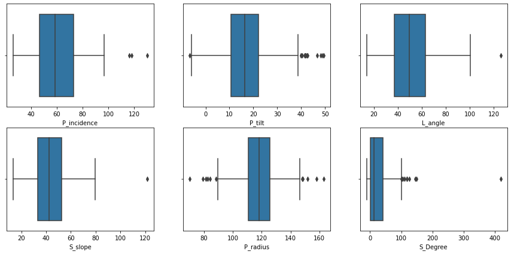

```python
plt.figure(figsize=(15,7))
cols=["P_incidence","P_tilt","L_angle","S_slope","P_radius","S_Degree"]
index = 1
for col in cols:
    plt.subplot(2,3,index)
    sns.boxplot(data=patients,x=col)
    index+= 1
```

## 3. Data Analysis: [10 Marks]

### A. Visualize a heatmap to understand correlation between all features [2 Marks]

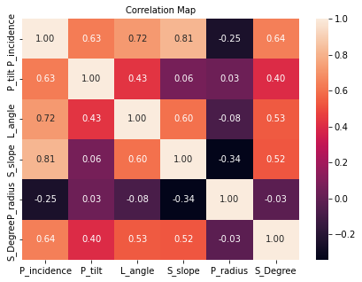

```python
#correlation map
plt.figure(figsize=(7,5))
corr_matrix = patients.corr(method='pearson')
sns.heatmap(corr_matrix, fmt='.2f',annot=True)
plt.title("Correlation Map", size=10)
plt.show()
```

- S_slope and P_incidence have high positive correlation
- S_slope and P_radius have negative correlation
- P_radius has negative correlation with P_incidence and S_Slope
- P_incidence has better correlation with all other features except for P_radius
- S_Degree has slight negative correlation with P_radius
- P_tilt has less correlation with P_radius and S_slope
- P_radius also has less correlation with S_Degree

### B. Share insights on correlation. [2 Marks]

#### A. Features having stronger correlation with correlation value.

- P_incidence has better correlation with all other features except for P_radius
- P_incidence has highest correlation with S_slope
- The second highest correlation is between P_incidence with L_angle

#### B. Features having weaker correlation with correlation value.

- P_tilt has less correlation with P_radius and S_slope
- P_radius also has less correlation with S_Degree
- P_radius also has less correlation with L_angle

### C. Visualize a pairplot with 3 classes distinguished by colors and share insights. [2 Marks]

```python
#patients.reindex(columns=['P_incidence','P_tilt','L_angle','S_slope','P_radius','S_Degree','Class'])
patients.reset_index(inplace=True,drop=True)
```

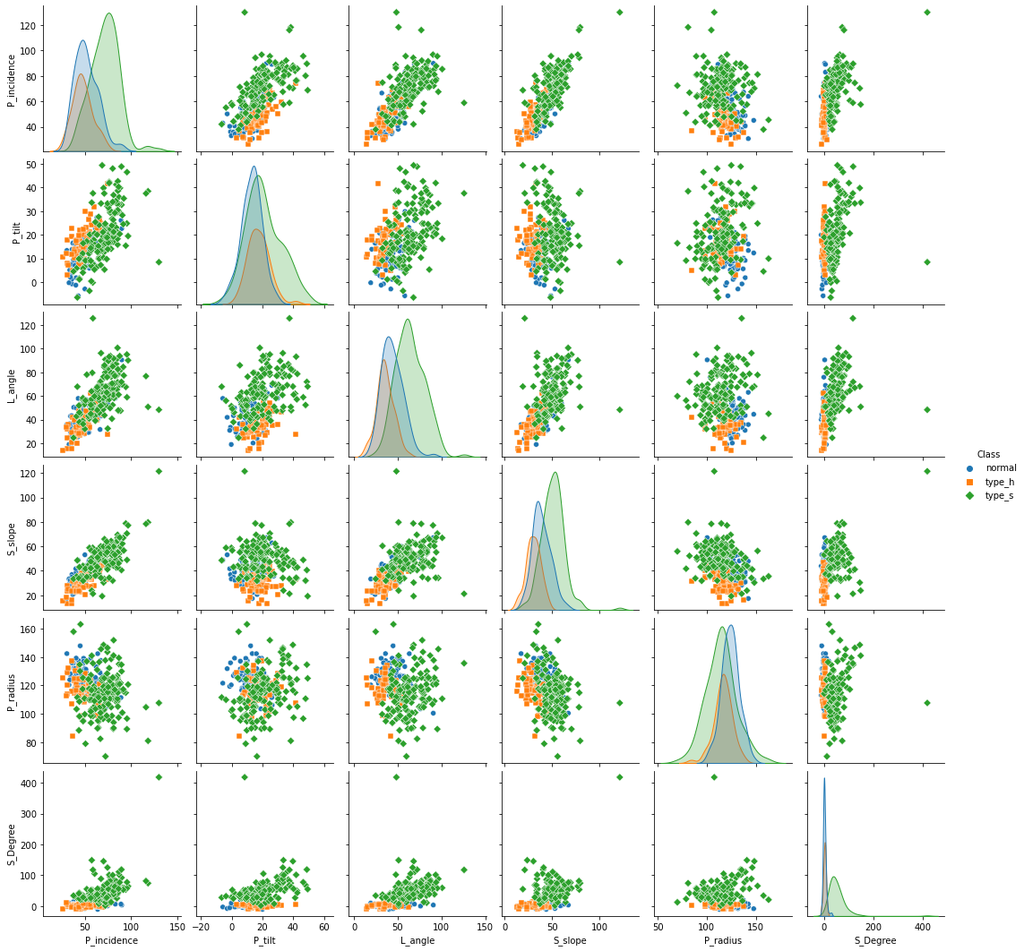

```python
#Pairplot for all numerical fields
plt.figure(figsize=(15,10))
sns.pairplot(patients,hue="Class",markers=["o", "s", "D"])
```

- S_slope and P_incidence have high positive correlation on all 3 classes
- S_slope and L_angle also have good positive correlation on all 3 classes
- P_incidence and L_angle also have good positive correlation on all 3 classes

#### D. Visualize a jointplot for ‘P_incidence’ and ‘S_slope’ and share insights. [2 Marks]

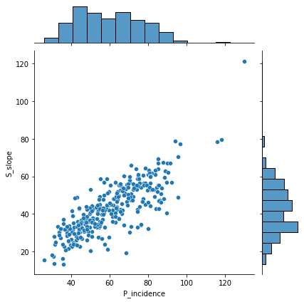

```python
#joint plot for  ‘P_incidence’ and ‘S_slope’
plt.figure(figsize=(15,10))
sns.jointplot(data=patients, x="P_incidence", y="S_slope")
```

###### In-sights:

- P_incidence and S_slope have good positive correlation

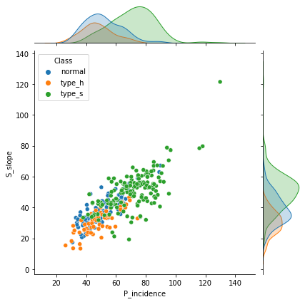

```python
#joint plot for  ‘P_incidence’ and ‘S_slope’
plt.figure(figsize=(15,10))
sns.jointplot(data=patients, x="P_incidence", y="S_slope", hue="Class")
```

###### In-sights:

- P_incidence and S_slope have good positive correlation for all 3 classess. For all the 3 classes the values are normally distributed.

#### E. Visualize a boxplot to check distribution of the features and share insights. [2 Marks]

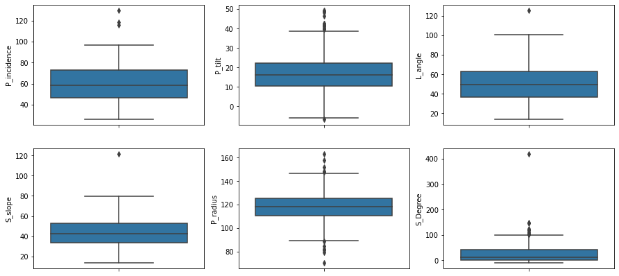

```python
plt.figure(figsize=(15,7))
cols=["P_incidence","P_tilt","L_angle","S_slope","P_radius", "S_Degree"]
index = 1
for col in cols:
    plt.subplot(2,3,index)
    sns.boxplot(data=patients,y=col)
    index+= 1
```

##### Insights:

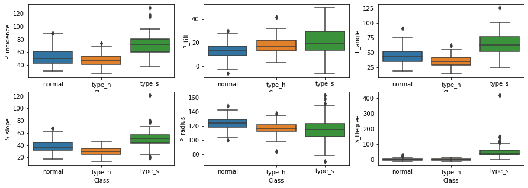

```python
plt.figure(figsize=(15,5))
cols=["P_incidence","P_tilt","L_angle","S_slope","P_radius", "S_Degree"]
index = 1
for col in cols:
    plt.subplot(2,3,index)
    sns.boxplot(data=patients,x="Class", y=col)
    index+= 1
```

##### Insights:

- S_Degree: Has extreme outliers for Type_S.
- Other feature too have outliers but in minimal counts.

In KNN classification, when K is bigger, the outliers do not greatly impact the score.

## 4. Model Building: [6 Marks]

### A. Split data into X and Y. [1 Marks]

```python
patients.head(5)
```

|  | P_incidence | P_tilt | L_angle | S_slope | P_radius | S_Degree | Class |
| --- | --- | --- | --- | --- | --- | --- | --- |
| 0 | 38.505273 | 16.964297 | 35.112814 | 21.540976 | 127.632875 | 7.986683 | normal |
| 1 | 54.920858 | 18.968430 | 51.601455 | 35.952428 | 125.846646 | 2.001642 | normal |
| 2 | 44.362490 | 8.945435 | 46.902096 | 35.417055 | 129.220682 | 4.994195 | normal |
| 3 | 48.318931 | 17.452121 | 48.000000 | 30.866809 | 128.980308 | -0.910941 | normal |
| 4 | 45.701789 | 10.659859 | 42.577846 | 35.041929 | 130.178314 | -3.388910 | normal |

```python
le=LabelEncoder()
patients['Class']=le.fit_transform(patients['Class'])
patients['Class'].value_counts()
```

```
2    150
0    100
1     60
Name: Class, dtype: int64
```

```python
patients.sample(n=10,random_state=1)
```

|  | P_incidence | P_tilt | L_angle | S_slope | P_radius | S_Degree | Class |
| --- | --- | --- | --- | --- | --- | --- | --- |
| 78 | 74.565015 | 15.724320 | 58.618582 | 58.840695 | 105.417304 | 0.599247 | 0 |
| 244 | 60.044177 | 14.309656 | 58.038865 | 45.734521 | 105.131664 | 30.409133 | 2 |
| 185 | 45.443750 | 9.906072 | 45.000000 | 35.537678 | 163.071041 | 20.315315 | 2 |
| 70 | 50.086153 | 13.430044 | 34.457541 | 36.656108 | 119.134622 | 3.089484 | 0 |
| 120 | 43.922840 | 14.177959 | 37.832547 | 29.744881 | 134.461016 | 6.451648 | 1 |
| 102 | 68.832021 | 22.218482 | 50.092194 | 46.613539 | 105.985135 | -3.530317 | 1 |
| 309 | 48.259920 | 16.417462 | 36.329137 | 31.842457 | 94.882336 | 28.343799 | 2 |
| 138 | 55.843286 | 28.847448 | 47.690543 | 26.995838 | 123.311845 | 2.812427 | 1 |
| 111 | 31.232387 | 17.715819 | 15.500000 | 13.516568 | 120.055399 | 0.499751 | 1 |
| 223 | 65.665347 | 10.540675 | 56.489135 | 55.124672 | 109.162777 | 53.932020 | 2 |

```python
X=patients.drop(columns=['Class'],axis=1)
y=patients[['Class']]
X.describe()
```

|  | P_incidence | P_tilt | L_angle | S_slope | P_radius | S_Degree |
| --- | --- | --- | --- | --- | --- | --- |
| count | 310.000000 | 310.000000 | 310.000000 | 310.000000 | 310.000000 | 310.000000 |
| mean | 60.496653 | 17.542822 | 51.930930 | 42.953831 | 117.920655 | 26.296694 |
| std | 17.236520 | 10.008330 | 18.554064 | 13.423102 | 13.317377 | 37.559027 |
| min | 26.147921 | -6.554948 | 14.000000 | 13.366931 | 70.082575 | -11.058179 |
| 25% | 46.430294 | 10.667069 | 37.000000 | 33.347122 | 110.709196 | 1.603727 |
| 50% | 58.691038 | 16.357689 | 49.562398 | 42.404912 | 118.268178 | 11.767934 |
| 75% | 72.877696 | 22.120395 | 63.000000 | 52.695888 | 125.467674 | 41.287352 |
| max | 129.834041 | 49.431864 | 125.742385 | 121.429566 | 163.071041 | 418.543082 |

```python
# since feature list are of different measurements - degree, radius, etc we need to prepare scaled data using zscore
X_scaled=X.apply(zscore)
X_scaled.describe()
```

|  | P_incidence | P_tilt | L_angle | S_slope | P_radius | S_Degree |
| --- | --- | --- | --- | --- | --- | --- |
| count | 3.100000e+02 | 3.100000e+02 | 3.100000e+02 | 3.100000e+02 | 3.100000e+02 | 3.100000e+02 |
| mean | 1.042177e-16 | 2.096889e-16 | 1.980495e-16 | 2.829278e-17 | -5.071212e-16 | -1.277204e-16 |
| std | 1.001617e+00 | 1.001617e+00 | 1.001617e+00 | 1.001617e+00 | 1.001617e+00 | 1.001617e+00 |
| min | -1.996010e+00 | -2.411664e+00 | -2.047652e+00 | -2.207741e+00 | -3.597963e+00 | -9.961725e-01 |
| 25% | -8.173982e-01 | -6.881138e-01 | -8.060267e-01 | -7.168418e-01 | -5.423830e-01 | -6.585073e-01 |
| 50% | -1.049246e-01 | -1.186061e-01 | -1.278621e-01 | -4.095971e-02 | 2.613767e-02 | -3.874502e-01 |
| 75% | 7.194643e-01 | 4.581158e-01 | 5.975493e-01 | 7.269414e-01 | 5.676209e-01 | 3.997679e-01 |
| max | 4.029206e+00 | 3.191402e+00 | 3.984615e+00 | 5.855771e+00 | 3.395818e+00 | 1.046035e+01 |

### B. Split data into train and test with 80:20 proportion. [1 Marks]

```python
X_train,X_test,y_train,y_test=train_test_split(X_scaled,y,test_size=0.20,random_state=1)
X_train
```

|  | P_incidence | P_tilt | L_angle | S_slope | P_radius | S_Degree |
| --- | --- | --- | --- | --- | --- | --- |
| 307 | 0.790186 | 0.128191 | 1.301073 | 0.919094 | 0.788596 | 1.255828 |
| 0 | -1.277922 | -0.057898 | -0.907904 | -1.597803 | 0.730468 | -0.488288 |
| 132 | -0.904193 | -0.009906 | -1.303725 | -1.153682 | 0.004488 | -0.552746 |
| 208 | 0.155522 | -1.122069 | 0.597549 | 1.036325 | -0.547285 | 0.434989 |
| 62 | -1.228329 | -1.053981 | -0.806027 | -0.791437 | -0.007664 | -0.650498 |
| ... | ... | ... | ... | ... | ... | ... |
| 203 | -0.622623 | -1.108469 | 0.057712 | 0.026974 | -0.530681 | -0.025629 |
| 255 | 0.366567 | -0.299356 | 1.087986 | 0.693908 | -2.667339 | 0.410385 |
| 72 | -0.395920 | -0.409901 | -0.558549 | -0.202775 | -0.301368 | -0.628284 |
| 235 | 0.966063 | 1.281708 | 1.379292 | 0.284868 | -0.549757 | 1.487981 |
| 37 | -0.619949 | -0.080702 | -1.291880 | -0.735901 | 0.264360 | -0.650251 |

248 rows × 6 columns

```python
y_train
```

|  | Class |
| --- | --- |
| 307 | 2 |
| 0 | 0 |
| 132 | 1 |
| 208 | 2 |
| 62 | 0 |
| ... | ... |
| 203 | 2 |
| 255 | 2 |
| 72 | 0 |
| 235 | 2 |
| 37 | 0 |

248 rows × 1 columns

```python
X_test
```

|  | P_incidence | P_tilt | L_angle | S_slope | P_radius | S_Degree |
| --- | --- | --- | --- | --- | --- | --- |
| 78 | 0.817515 | -0.181993 | 0.361024 | 1.185460 | -0.940393 | -0.685295 |
| 244 | -0.026293 | -0.323570 | 0.329729 | 0.207492 | -0.961876 | 0.109670 |
| 185 | -0.874727 | -0.764273 | -0.374157 | -0.553385 | 3.395818 | -0.159510 |
| 70 | -0.604956 | -0.411600 | -0.943278 | -0.469929 | 0.091304 | -0.618885 |
| 120 | -0.963107 | -0.336750 | -0.761083 | -0.985637 | 1.244021 | -0.529224 |
| ... | ... | ... | ... | ... | ... | ... |
| 146 | -0.706853 | 0.468863 | -0.850186 | -1.257252 | -0.040315 | -0.528422 |
| 9 | 0.221703 | 0.879243 | -0.052470 | -0.370881 | -0.883199 | -0.618119 |
| 127 | -0.982973 | -0.103475 | -0.266190 | -1.185078 | -0.650504 | -0.461456 |
| 16 | 0.201228 | -0.148304 | 0.604229 | 0.368971 | 1.838123 | -0.533295 |
| 206 | 0.262491 | -0.771059 | 0.313370 | 0.911968 | -1.743557 | 0.624034 |

62 rows × 6 columns

```python
y_test
```

|  | Class |
| --- | --- |
| 78 | 0 |
| 244 | 2 |
| 185 | 2 |
| 70 | 0 |
| 120 | 1 |
| ... | ... |
| 146 | 1 |
| 9 | 0 |
| 127 | 1 |
| 16 | 0 |
| 206 | 2 |

62 rows × 1 columns

### C. Train a Supervised Learning Classification base model using KNN classifier. [2 Marks]

```python
knn = KNeighborsClassifier(n_neighbors= 10 , metric = 'euclidean')
```

```python
# Call Nearest Neighbour algorithm

knn.fit(X_train, y_train)
```

```
KNeighborsClassifier(metric='euclidean', n_neighbors=10)
```

```python
knn.score(X_train, y_train)
```

```
0.8387096774193549
```

```python
knn.score(X_test, y_test)
```

```
0.7096774193548387
```

#### Training accuracy is 83% and testing accuracy is 70% Performance is less in test data.

This is due to overfitting of data

#### The correct K value which gives the maximum score accuracy is identified below.

### D. Print all the possible performance metrics for both train and test data. [2 Marks]

```python
predicted_labels_train = knn.predict(X_train)
```

```
Confusion Matrix
```

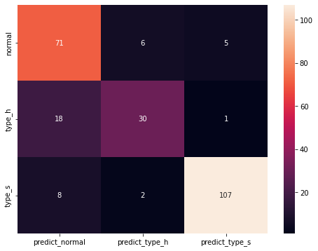

```python
# calculate accuracy measures and confusion matrix
from sklearn import metrics

print("Confusion Matrix")
cm_train=metrics.confusion_matrix(y_train, predicted_labels_train, labels=[0,1,2])

df_cm_train = pd.DataFrame(cm_train, index = [i for i in ["normal","type_h","type_s"]],
                  columns = [i for i in ["predict_normal","predict_type_h","predict_type_s"]])
plt.figure(figsize = (8,6))
sns.heatmap(df_cm_train, annot=True,fmt='g')
```

```python
print("classification  Matrix:\n",classification_report(y_train,predicted_labels_train))
```

```
classification  Matrix:
               precision    recall  f1-score   support

           0       0.73      0.87      0.79        82
           1       0.79      0.61      0.69        49
           2       0.95      0.91      0.93       117

    accuracy                           0.84       248
   macro avg       0.82      0.80      0.80       248
weighted avg       0.84      0.84      0.84       248
```

###### Insights on training data prediction:

Precision: Out of all predicted values, what fraction are predicted correctly  
Recall(sensitivity or TPR): Out of all actual values how much fraction we identified correctly

- class 0, the model predicted correctly for 73% of time.
- class 1, the model predicted correctly for 79% and for class 2 the model predicted correctly for 95% of time.
- By F1 score we can say that precison and recall is balanced for class 0 by 79% and for class 1 by 69%
- We have maximum F1 score for class 2 i.e 93%.

```python
predicted_labels_test = knn.predict(X_test)
```

```
Confusion Matrix
```

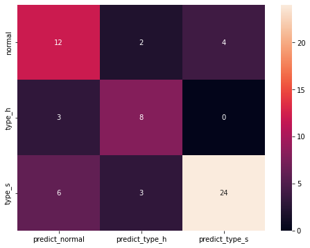

```python
print("Confusion Matrix")
cm_test=metrics.confusion_matrix(y_test, predicted_labels_test, labels=[0,1,2])

df_cm_test = pd.DataFrame(cm_test, index = [i for i in ["normal","type_h","type_s"]],
                  columns = [i for i in ["predict_normal","predict_type_h","predict_type_s"]])
plt.figure(figsize = (8,6))
sns.heatmap(df_cm_test, annot=True,fmt='g')
```

```python
print("classification  Matrix:\n",classification_report(y_test,predicted_labels_test))
```

```
classification  Matrix:
               precision    recall  f1-score   support

           0       0.57      0.67      0.62        18
           1       0.62      0.73      0.67        11
           2       0.86      0.73      0.79        33

    accuracy                           0.71        62
   macro avg       0.68      0.71      0.69        62
weighted avg       0.73      0.71      0.72        62
```

###### Insights on test data prediction:

Precision: Out of all predicted values, what fraction are predicted correctly  
Recall(sensitivity or TPR): Out of all actual values how much fraction we identified correctly

- class 0, the model predicted correctly for 57% of time.
- class 1, the model predicted correctly for 62% and for class 2 the model predicted correctly for 86% of time.
- By F1 score we can say that precison and recall is balanced for class 0 by 62% and for class 1 by 67%
- We have maximum F1 score for class 2 i.e 79%.

When comparing F1 scores for train and test, test F1 score is not promising. May be the model was overfit in training set. We need to find out the optimal K value.

```python
#for this population, assuming k is less than 20, let us find out the best k value
train_score=[]
test_score=[]
for k in range(1,21):
    knn = KNeighborsClassifier(n_neighbors= k , metric = 'euclidean' )
    knn.fit(X_train, y_train.values.ravel())
    train_score.append(knn.score(X_train, y_train.values.ravel()))
    test_score.append(knn.score(X_test, y_test.values.ravel()))
```

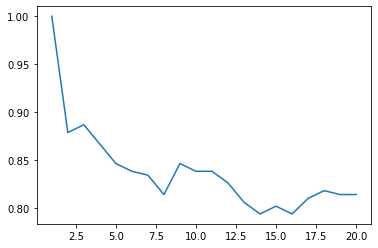

```python
plt.plot(range(1,21),train_score)
plt.show()
```

##### Insight:

- As we increase the value of K, the accuracy of the score goes down in training set.

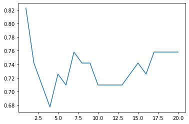

```python
plt.plot(range(1,21),test_score)
plt.show()
```

##### Insight:

```python
# Finding the exact best k value between 1 to 20
for k in range(1,21):
    knn = KNeighborsClassifier(n_neighbors= k , metric = 'euclidean')
    knn.fit(X_train, y_train.values.ravel())
    predicted_labels = knn.predict(X_test)
    print('Accuracy on Training data for k {} is {}:'.format(k,knn.score(X_train, y_train.values.ravel())))
    print('Accuracy on Test data for k {} is {}:'.format(k,knn.score(X_test, y_test.values.ravel())))
    print("classification  Matrix:\n",classification_report(y_test,predicted_labels))
```

```
Accuracy on Training data for k 1 is 1.0:
Accuracy on Test data for k 1 is 0.8225806451612904:
classification  Matrix:
               precision    recall  f1-score   support

           0       0.74      0.78      0.76        18
           1       0.75      0.82      0.78        11
           2       0.90      0.85      0.88        33

    accuracy                           0.82        62
   macro avg       0.80      0.81      0.80        62
weighted avg       0.83      0.82      0.82        62

Accuracy on Training data for k 2 is 0.8790322580645161:
Accuracy on Test data for k 2 is 0.7419354838709677:
classification  Matrix:
               precision    recall  f1-score   support

           0       0.59      0.89      0.71        18
           1       0.67      0.55      0.60        11
           2       0.92      0.73      0.81        33

    accuracy                           0.74        62
   macro avg       0.73      0.72      0.71        62
weighted avg       0.78      0.74      0.75        62

Accuracy on Training data for k 3 is 0.8870967741935484:
Accuracy on Test data for k 3 is 0.7096774193548387:
classification  Matrix:
               precision    recall  f1-score   support

           0       0.57      0.72      0.63        18
           1       0.64      0.64      0.64        11
           2       0.86      0.73      0.79        33

    accuracy                           0.71        62
   macro avg       0.69      0.70      0.69        62
weighted avg       0.73      0.71      0.72        62

Accuracy on Training data for k 4 is 0.8669354838709677:
```

[output cut: 204 more lines]

```
   macro avg       0.72      0.74      0.73        62
weighted avg       0.77      0.76      0.76        62

Accuracy on Training data for k 20 is 0.8145161290322581:
Accuracy on Test data for k 20 is 0.7580645161290323:
classification  Matrix:
               precision    recall  f1-score   support

           0       0.63      0.67      0.65        18
           1       0.67      0.73      0.70        11
           2       0.87      0.82      0.84        33

    accuracy                           0.76        62
   macro avg       0.72      0.74      0.73        62
weighted avg       0.77      0.76      0.76        62
```

##### Insights:

Precision: Out of all predicted values, what fraction are predicted correctly  
Recall(sensitivity or TPR): Out of all actual values how much fraction we identified correctly

- class 0, the model predicted correctly for 60% of time.
- class 1, the model predicted correctly for 75% and for class 2 the model predicted correctly for 87% of time.
- By F1 score we can say that precison and recall is balanced for class 0 by 63% and for class 1 by 78%
- We have maximum F1 score for class 2 i.e 83%.

Accuracy on Training data for k 7 is 0.8346774193548387 Accuracy on Test data for k 7 is 0.7580645161290323

When K value increases i.e when k=8, the precision value decreases further.

#### Finalized K value=7

## 5. Performance Improvement: [4 Marks]

### A. Experiment with various parameters to improve performance of the base model. [2 Marks]

```python
#Try with various hyperparameters and to indentify the best model
from sklearn.model_selection import GridSearchCV
leaf_size = list(range(1,50))
n_neighbors = list(range(3,50))
p=[1,2]
#prepare hyperparameters dict
hyperparameters = dict(leaf_size=leaf_size, n_neighbors=n_neighbors, p=p)
#Lets create new KNN object
knn_hyper = KNeighborsClassifier()
#We will use GridSearch
clf = GridSearchCV(knn_hyper, hyperparameters, cv=10)
#Fit the model
knn_best = clf.fit(X_train, y_train.values.ravel())
#Print the best values of Hyperparameters
print('Best of leaf_size:', knn_best.best_estimator_.get_params()['leaf_size'])
print('Best of p:', knn_best.best_estimator_.get_params()['p'])
print('Best of n_neighbors:', knn_best.best_estimator_.get_params()['n_neighbors'])
```

```
Best of leaf_size: 1
Best of p: 2
Best of n_neighbors: 7
```

```python
#Lets calculate the score using the best of hypermeters identified above.
hyperparameters=dict(leaf_size=[1], n_neighbors=[7], p=[2])
#Use GridSearch
clf = GridSearchCV(knn_hyper, hyperparameters, cv=10)
#Fit the model
knn_best_model = clf.fit(X_train, y_train.values.ravel())
```

```python
predicted_labels = knn_best_model.predict(X_test)
print('Accuracy on Training data is {}:'.format(knn_best_model.score(X_train, y_train.values.ravel())))
print('Accuracy on Test data is {}:'.format(knn_best_model.score(X_test, y_test.values.ravel())))
print("classification  Matrix:\n",classification_report(y_test,predicted_labels))
```

```
Accuracy on Training data is 0.8346774193548387:
Accuracy on Test data is 0.7580645161290323:
classification  Matrix:
               precision    recall  f1-score   support

           0       0.60      0.67      0.63        18
           1       0.75      0.82      0.78        11
           2       0.87      0.79      0.83        33

    accuracy                           0.76        62
   macro avg       0.74      0.76      0.75        62
weighted avg       0.77      0.76      0.76        62
```

### B. Clearly showcase improvement in performance achieved. [1 Marks]

For Example: A. Accuracy: +15% improvement  
B. Precision: +10% improvemen

### Insights:

Precision: Out of all predicted values, what fraction are predicted correctly  
Recall(sensitivity or TPR): Out of all actual values how much fraction we identified correctly

- class 0, the model predicted correctly for 60% of time.
- class 1, the model predicted correctly for 75% and for class 2 the model predicted correctly for 87% of time.
- By F1 score we can say that precison and recall is balanced for class 0 by 63% and for class 1 by 78%
- We have maximum F1 score for class 2 i.e 83%.

#### Accuracy on Training data for k=7, leaf size=1, p=2 is 0.8346774193548387

#### Accuracy on Test data for k=7,leaf size=1, p=2 is 0.7580645161290323

#### Before tuning:

Accuracy of test data is 0.7096774193548387 classification Matrix: precision recall f1-score support

```
       0       0.57      0.67      0.62        18
       1       0.62      0.73      0.67        11
       2       0.86      0.73      0.79        33

accuracy                           0.71        62
```

macro avg 0.68 0.71 0.69 62 weighted avg 0.73 0.71 0.72 62

### C. Clearly state which parameters contributed most to improve model performance. [1 Marks]

##### Answer: Setting n_neighbors = 7 for metric = 'euclidean' is the most driving parameter which contributed to improve model performance. The score has improved to 75.8%.

# Part B - 30 Marks

## 1. Data Understanding and Preparation: [5 Marks]

### A. Read both the Datasets ‘Data1’ and ‘Data 2’ as DataFrame and store them into two separate variables. [1 Marks]

```python
data1=pd.read_csv("Part2-Data1.csv")
data1.head()
```

|  | ID | Age | CustomerSince | HighestSpend | ZipCode | HiddenScore | MonthlyAverageSpend | Level |
| --- | --- | --- | --- | --- | --- | --- | --- | --- |
| 0 | 1 | 25 | 1 | 49 | 91107 | 4 | 1.6 | 1 |
| 1 | 2 | 45 | 19 | 34 | 90089 | 3 | 1.5 | 1 |
| 2 | 3 | 39 | 15 | 11 | 94720 | 1 | 1.0 | 1 |
| 3 | 4 | 35 | 9 | 100 | 94112 | 1 | 2.7 | 2 |
| 4 | 5 | 35 | 8 | 45 | 91330 | 4 | 1.0 | 2 |

```python
data2=pd.read_csv("Part2-Data2.csv")
data2.head()
```

|  | ID | Mortgage | Security | FixedDepositAccount | InternetBanking | CreditCard | LoanOnCard |
| --- | --- | --- | --- | --- | --- | --- | --- |
| 0 | 1 | 0 | 1 | 0 | 0 | 0 | NaN |
| 1 | 2 | 0 | 1 | 0 | 0 | 0 | NaN |
| 2 | 3 | 0 | 0 | 0 | 0 | 0 | NaN |
| 3 | 4 | 0 | 0 | 0 | 0 | 0 | NaN |
| 4 | 5 | 0 | 0 | 0 | 0 | 1 | NaN |

### B. Print shape and Column Names and DataTypes of both the Dataframes. [1 Marks]

```python
data1.shape
```

```
(5000, 8)
```

```python
data1.columns
```

```
Index(['ID', 'Age', 'CustomerSince', 'HighestSpend', 'ZipCode', 'HiddenScore',
       'MonthlyAverageSpend', 'Level'],
      dtype='object')
```

```python
data1.dtypes
```

```
ID                       int64
Age                      int64
CustomerSince            int64
HighestSpend             int64
ZipCode                  int64
HiddenScore              int64
MonthlyAverageSpend    float64
Level                    int64
dtype: object
```

```python
data1.info()
```

```
<class 'pandas.core.frame.DataFrame'>
RangeIndex: 5000 entries, 0 to 4999
Data columns (total 8 columns):
 #   Column               Non-Null Count  Dtype
---  ------               --------------  -----
 0   ID                   5000 non-null   int64
 1   Age                  5000 non-null   int64
 2   CustomerSince        5000 non-null   int64
 3   HighestSpend         5000 non-null   int64
 4   ZipCode              5000 non-null   int64
 5   HiddenScore          5000 non-null   int64
 6   MonthlyAverageSpend  5000 non-null   float64
 7   Level                5000 non-null   int64
dtypes: float64(1), int64(7)
memory usage: 312.6 KB
```

```python
data2.shape
```

```
(5000, 7)
```

```python
data2.columns
```

```
Index(['ID', 'Mortgage', 'Security', 'FixedDepositAccount', 'InternetBanking',
       'CreditCard', 'LoanOnCard'],
      dtype='object')
```

```python
data2.dtypes
```

```
ID                       int64
Mortgage                 int64
Security                 int64
FixedDepositAccount      int64
InternetBanking          int64
CreditCard               int64
LoanOnCard             float64
dtype: object
```

```python
data2.info()
```

```
<class 'pandas.core.frame.DataFrame'>
RangeIndex: 5000 entries, 0 to 4999
Data columns (total 7 columns):
 #   Column               Non-Null Count  Dtype
---  ------               --------------  -----
 0   ID                   5000 non-null   int64
 1   Mortgage             5000 non-null   int64
 2   Security             5000 non-null   int64
 3   FixedDepositAccount  5000 non-null   int64
 4   InternetBanking      5000 non-null   int64
 5   CreditCard           5000 non-null   int64
 6   LoanOnCard           4980 non-null   float64
dtypes: float64(1), int64(6)
memory usage: 273.6 KB
```

### C. Merge both the Dataframes on ‘ID’ feature to form a single DataFrame [2 Marks]

```python
cust=data1.merge(data2, how='left', on='ID')
cust.head()
```

|  | ID | Age | CustomerSince | HighestSpend | ZipCode | HiddenScore | MonthlyAverageSpend | Level | Mortgage | Security | FixedDepositAccount | InternetBanking | CreditCard | LoanOnCard |
| --- | --- | --- | --- | --- | --- | --- | --- | --- | --- | --- | --- | --- | --- | --- |
| 0 | 1 | 25 | 1 | 49 | 91107 | 4 | 1.6 | 1 | 0 | 1 | 0 | 0 | 0 | NaN |
| 1 | 2 | 45 | 19 | 34 | 90089 | 3 | 1.5 | 1 | 0 | 1 | 0 | 0 | 0 | NaN |
| 2 | 3 | 39 | 15 | 11 | 94720 | 1 | 1.0 | 1 | 0 | 0 | 0 | 0 | 0 | NaN |
| 3 | 4 | 35 | 9 | 100 | 94112 | 1 | 2.7 | 2 | 0 | 0 | 0 | 0 | 0 | NaN |
| 4 | 5 | 35 | 8 | 45 | 91330 | 4 | 1.0 | 2 | 0 | 0 | 0 | 0 | 1 | NaN |

```python
cust.shape
```

```
(5000, 14)
```

```python
cust.info()
```

```
<class 'pandas.core.frame.DataFrame'>
Int64Index: 5000 entries, 0 to 4999
Data columns (total 14 columns):
 #   Column               Non-Null Count  Dtype
---  ------               --------------  -----
 0   ID                   5000 non-null   int64
 1   Age                  5000 non-null   int64
 2   CustomerSince        5000 non-null   int64
 3   HighestSpend         5000 non-null   int64
 4   ZipCode              5000 non-null   int64
 5   HiddenScore          5000 non-null   int64
 6   MonthlyAverageSpend  5000 non-null   float64
 7   Level                5000 non-null   int64
 8   Mortgage             5000 non-null   int64
 9   Security             5000 non-null   int64
 10  FixedDepositAccount  5000 non-null   int64
 11  InternetBanking      5000 non-null   int64
 12  CreditCard           5000 non-null   int64
 13  LoanOnCard           4980 non-null   float64
dtypes: float64(2), int64(12)
memory usage: 585.9 KB
```

```python
cust.describe()
```

|  | ID | Age | CustomerSince | HighestSpend | ZipCode | HiddenScore | MonthlyAverageSpend | Level | Mortgage | Security | FixedDepositAccount | InternetBanking | CreditCard | LoanOnCard |
| --- | --- | --- | --- | --- | --- | --- | --- | --- | --- | --- | --- | --- | --- | --- |
| count | 5000.000000 | 5000.000000 | 5000.000000 | 5000.000000 | 5000.000000 | 5000.000000 | 5000.000000 | 5000.000000 | 5000.000000 | 5000.000000 | 5000.00000 | 5000.000000 | 5000.000000 | 4980.000000 |
| mean | 2500.500000 | 45.338400 | 20.104600 | 73.774200 | 93152.503000 | 2.396400 | 1.937938 | 1.881000 | 56.498800 | 0.104400 | 0.06040 | 0.596800 | 0.294000 | 0.096386 |
| std | 1443.520003 | 11.463166 | 11.467954 | 46.033729 | 2121.852197 | 1.147663 | 1.747659 | 0.839869 | 101.713802 | 0.305809 | 0.23825 | 0.490589 | 0.455637 | 0.295149 |
| min | 1.000000 | 23.000000 | -3.000000 | 8.000000 | 9307.000000 | 1.000000 | 0.000000 | 1.000000 | 0.000000 | 0.000000 | 0.00000 | 0.000000 | 0.000000 | 0.000000 |
| 25% | 1250.750000 | 35.000000 | 10.000000 | 39.000000 | 91911.000000 | 1.000000 | 0.700000 | 1.000000 | 0.000000 | 0.000000 | 0.00000 | 0.000000 | 0.000000 | 0.000000 |
| 50% | 2500.500000 | 45.000000 | 20.000000 | 64.000000 | 93437.000000 | 2.000000 | 1.500000 | 2.000000 | 0.000000 | 0.000000 | 0.00000 | 1.000000 | 0.000000 | 0.000000 |
| 75% | 3750.250000 | 55.000000 | 30.000000 | 98.000000 | 94608.000000 | 3.000000 | 2.500000 | 3.000000 | 101.000000 | 0.000000 | 0.00000 | 1.000000 | 1.000000 | 0.000000 |
| max | 5000.000000 | 67.000000 | 43.000000 | 224.000000 | 96651.000000 | 4.000000 | 10.000000 | 3.000000 | 635.000000 | 1.000000 | 1.00000 | 1.000000 | 1.000000 | 1.000000 |

### D. Change Datatype of below features to ‘Object’ [1 Marks]

‘CreditCard’, ‘InternetBanking’, ‘FixedDepositAccount’, ‘Security’, ‘Level’, ‘HiddenScore’

```python
cust["CreditCard"]=cust["CreditCard"].astype("object")
cust["InternetBanking"]=cust["InternetBanking"].astype("object")
cust["FixedDepositAccount"]=cust["FixedDepositAccount"].astype("object")
cust["Security"]=cust["Security"].astype("object")
cust["Level"]=cust["Level"].astype("object")
cust["HiddenScore"]=cust["HiddenScore"].astype("object")
```

```python
cust.dtypes
```

```
ID                       int64
Age                      int64
CustomerSince            int64
HighestSpend             int64
ZipCode                  int64
HiddenScore             object
MonthlyAverageSpend    float64
Level                   object
Mortgage                 int64
Security                object
FixedDepositAccount     object
InternetBanking         object
CreditCard              object
LoanOnCard             float64
dtype: object
```

```python
cust.info()
```

```
<class 'pandas.core.frame.DataFrame'>
Int64Index: 5000 entries, 0 to 4999
Data columns (total 14 columns):
 #   Column               Non-Null Count  Dtype
---  ------               --------------  -----
 0   ID                   5000 non-null   int64
 1   Age                  5000 non-null   int64
 2   CustomerSince        5000 non-null   int64
 3   HighestSpend         5000 non-null   int64
 4   ZipCode              5000 non-null   int64
 5   HiddenScore          5000 non-null   object
 6   MonthlyAverageSpend  5000 non-null   float64
 7   Level                5000 non-null   object
 8   Mortgage             5000 non-null   int64
 9   Security             5000 non-null   object
 10  FixedDepositAccount  5000 non-null   object
 11  InternetBanking      5000 non-null   object
 12  CreditCard           5000 non-null   object
 13  LoanOnCard           4980 non-null   float64
dtypes: float64(2), int64(6), object(6)
memory usage: 585.9+ KB
```

## 2. Data Exploration and Analysis: [5 Marks]

### A. Visualize distribution of Target variable ‘LoanOnCard’ and clearly share insights. [2 Marks]

```python
cust["LoanOnCard"].value_counts()
```

```
0.0    4500
1.0     480
Name: LoanOnCard, dtype: int64
```

Total record counts=5000  
LoanOnCard=4500+480= 4980  
There should be some null values

```python
cust["LoanOnCard"].isnull().sum()
```

```
20
```

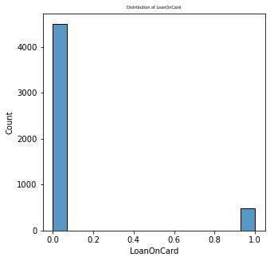

```python
plt.figure(figsize=(5,5))
sns.histplot(data=cust, x='LoanOnCard')
plt.title("Distribution of LoanOnCard",size=5)
plt.show()
```

### B. Check the percentage of missing values and impute if required. [1 Marks]

```python
null_percentage=[{col : cust[col].isnull().sum()*100/len(cust)} for col in cust.columns]
null_percentage
```

```
[{'ID': 0.0},
 {'Age': 0.0},
 {'CustomerSince': 0.0},
 {'HighestSpend': 0.0},
 {'ZipCode': 0.0},
 {'HiddenScore': 0.0},
 {'MonthlyAverageSpend': 0.0},
 {'Level': 0.0},
 {'Mortgage': 0.0},
 {'Security': 0.0},
 {'FixedDepositAccount': 0.0},
 {'InternetBanking': 0.0},
 {'CreditCard': 0.0},
 {'LoanOnCard': 0.4}]
```

LoanOnCard has 0.4 percentage null values. Since LoanOncard represents if the customer has a loan on credit card or not, and we have very less percentage of null values, we need not impute any value for nulls. Instead we can drop the records.

```python
customer=cust.dropna()
customer.shape
```

```
(4980, 14)
```

### C. Check for unexpected values in each categorical variable and impute with best suitable value. [2 Marks]

```python
customer["HiddenScore"].value_counts()
```

```
1    1466
2    1293
4    1215
3    1006
Name: HiddenScore, dtype: int64
```

```python
1466+1293+1215+1006
```

```
4980
```

customer["HiddenScore"] had 4 different values 1,2,3,4 and there are no unexpected values. So HiddenScore can be kept as it is.

```python
customer["Level"].value_counts()
```

```
1    2089
3    1496
2    1395
Name: Level, dtype: int64
```

```python
2089+1496+1395
```

```
4980
```

customer["Level"] had 3 different values 1,2,3 and there are no unexpected values. So Level can be kept as it is.

```python
customer["Security"].value_counts()
```

```
0    4460
1     520
Name: Security, dtype: int64
```

```python
4460+520
```

```
4980
```

customer["Security"] had 2 different values 0,1 and there are no unexpected values. So Security can be kept as it is.

```python
customer["FixedDepositAccount"].value_counts()
```

```
0    4678
1     302
Name: FixedDepositAccount, dtype: int64
```

```python
4678+302
```

```
4980
```

customer["FixedDepositAccount"] had 2 different values 0,1 and there are no unexpected values. So FixedDepositAccount can be kept as it is.

```python
customer["InternetBanking"].value_counts()
```

```
1    2974
0    2006
Name: InternetBanking, dtype: int64
```

```python
2974+2006
```

```
4980
```

customer["InternetBanking"] had 2 different values 0,1 and there are no unexpected values. So InternetBanking can be kept as it is.

```python
customer["CreditCard"].value_counts()
```

```
0    3514
1    1466
Name: CreditCard, dtype: int64
```

```python
3514+1466
```

```
4980
```

customer["CreditCard"] had 2 different values 0,1 and there are no unexpected values. So CreditCard can be kept as it is.

## 3. Data Preparation and model building: [10 Marks]

### A. Split data into X and Y. [1 Marks]

[Recommended to drop ID & ZipCode. LoanOnCard is target Variable]

```python
customer.drop(['ID','ZipCode'],axis=1,inplace=True)
customer.head()
```

|  | Age | CustomerSince | HighestSpend | HiddenScore | MonthlyAverageSpend | Level | Mortgage | Security | FixedDepositAccount | InternetBanking | CreditCard | LoanOnCard |
| --- | --- | --- | --- | --- | --- | --- | --- | --- | --- | --- | --- | --- |
| 9 | 34 | 9 | 180 | 1 | 8.9 | 3 | 0 | 0 | 0 | 0 | 0 | 1.0 |
| 10 | 65 | 39 | 105 | 4 | 2.4 | 3 | 0 | 0 | 0 | 0 | 0 | 0.0 |
| 11 | 29 | 5 | 45 | 3 | 0.1 | 2 | 0 | 0 | 0 | 1 | 0 | 0.0 |
| 12 | 48 | 23 | 114 | 2 | 3.8 | 3 | 0 | 1 | 0 | 0 | 0 | 0.0 |
| 13 | 59 | 32 | 40 | 4 | 2.5 | 2 | 0 | 0 | 0 | 1 | 0 | 0.0 |

```python
customer.info()
```

```
<class 'pandas.core.frame.DataFrame'>
Int64Index: 4980 entries, 9 to 4999
Data columns (total 12 columns):
 #   Column               Non-Null Count  Dtype
---  ------               --------------  -----
 0   Age                  4980 non-null   int64
 1   CustomerSince        4980 non-null   int64
 2   HighestSpend         4980 non-null   int64
 3   HiddenScore          4980 non-null   object
 4   MonthlyAverageSpend  4980 non-null   float64
 5   Level                4980 non-null   object
 6   Mortgage             4980 non-null   int64
 7   Security             4980 non-null   object
 8   FixedDepositAccount  4980 non-null   object
 9   InternetBanking      4980 non-null   object
 10  CreditCard           4980 non-null   object
 11  LoanOnCard           4980 non-null   float64
dtypes: float64(2), int64(4), object(6)
memory usage: 505.8+ KB
```

```python
customer["MonthlyAverageSpend"].value_counts()
```

```
0.30    240
1.00    229
0.20    204
2.00    188
0.80    187
       ...
8.90      1
3.67      1
4.67      1
3.25      1
2.75      1
Name: MonthlyAverageSpend, Length: 108, dtype: int64
```

```python
customer.loc[customer["MonthlyAverageSpend"]==0]
```

|  | Age | CustomerSince | HighestSpend | HiddenScore | MonthlyAverageSpend | Level | Mortgage | Security | FixedDepositAccount | InternetBanking | CreditCard | LoanOnCard |
| --- | --- | --- | --- | --- | --- | --- | --- | --- | --- | --- | --- | --- |
| 63 | 42 | 17 | 32 | 4 | 0.0 | 2 | 0 | 0 | 0 | 1 | 0 | 0.0 |
| 128 | 38 | 14 | 74 | 2 | 0.0 | 1 | 0 | 1 | 0 | 1 | 0 | 0.0 |
| 198 | 27 | 3 | 59 | 4 | 0.0 | 1 | 90 | 1 | 0 | 1 | 0 | 0.0 |
| 210 | 51 | 26 | 20 | 2 | 0.0 | 1 | 0 | 0 | 0 | 0 | 0 | 0.0 |
| 215 | 38 | 14 | 92 | 2 | 0.0 | 1 | 249 | 0 | 0 | 1 | 1 | 0.0 |
| ... | ... | ... | ... | ... | ... | ... | ... | ... | ... | ... | ... | ... |
| 4801 | 34 | 10 | 88 | 2 | 0.0 | 1 | 121 | 0 | 0 | 1 | 0 | 0.0 |
| 4826 | 56 | 31 | 81 | 2 | 0.0 | 3 | 225 | 0 | 0 | 0 | 0 | 0.0 |
| 4837 | 36 | 10 | 183 | 2 | 0.0 | 1 | 0 | 0 | 0 | 0 | 0 | 0.0 |
| 4910 | 48 | 22 | 120 | 1 | 0.0 | 1 | 0 | 0 | 0 | 1 | 0 | 0.0 |
| 4949 | 29 | 5 | 64 | 4 | 0.0 | 1 | 249 | 0 | 0 | 0 | 1 | 0.0 |

106 rows × 12 columns

```python
customer.describe()
```

|  | Age | CustomerSince | HighestSpend | MonthlyAverageSpend | Mortgage | LoanOnCard |
| --- | --- | --- | --- | --- | --- | --- |
| count | 4980.000000 | 4980.000000 | 4980.00000 | 4980.000000 | 4980.000000 | 4980.000000 |
| mean | 45.352610 | 20.117671 | 73.85241 | 1.939536 | 56.589759 | 0.096386 |
| std | 11.464212 | 11.468716 | 46.07009 | 1.750006 | 101.836758 | 0.295149 |
| min | 23.000000 | -3.000000 | 8.00000 | 0.000000 | 0.000000 | 0.000000 |
| 25% | 35.000000 | 10.000000 | 39.00000 | 0.700000 | 0.000000 | 0.000000 |
| 50% | 45.000000 | 20.000000 | 64.00000 | 1.500000 | 0.000000 | 0.000000 |
| 75% | 55.000000 | 30.000000 | 98.00000 | 2.525000 | 101.000000 | 0.000000 |
| max | 67.000000 | 43.000000 | 224.00000 | 10.000000 | 635.000000 | 1.000000 |

```python
X=customer.drop(columns=['LoanOnCard'],axis=1)
y=customer[['LoanOnCard']]
X.describe()
```

|  | Age | CustomerSince | HighestSpend | MonthlyAverageSpend | Mortgage |
| --- | --- | --- | --- | --- | --- |
| count | 4980.000000 | 4980.000000 | 4980.00000 | 4980.000000 | 4980.000000 |
| mean | 45.352610 | 20.117671 | 73.85241 | 1.939536 | 56.589759 |
| std | 11.464212 | 11.468716 | 46.07009 | 1.750006 | 101.836758 |
| min | 23.000000 | -3.000000 | 8.00000 | 0.000000 | 0.000000 |
| 25% | 35.000000 | 10.000000 | 39.00000 | 0.700000 | 0.000000 |
| 50% | 45.000000 | 20.000000 | 64.00000 | 1.500000 | 0.000000 |
| 75% | 55.000000 | 30.000000 | 98.00000 | 2.525000 | 101.000000 |
| max | 67.000000 | 43.000000 | 224.00000 | 10.000000 | 635.000000 |

### B. Split data into train and test. Keep 25% data reserved for testing. [1 Marks]

```python
X_train,X_test,y_train,y_test=train_test_split(X,y,test_size=0.25,random_state=1)
X_train
```

|  | Age | CustomerSince | HighestSpend | HiddenScore | MonthlyAverageSpend | Level | Mortgage | Security | FixedDepositAccount | InternetBanking | CreditCard |
| --- | --- | --- | --- | --- | --- | --- | --- | --- | --- | --- | --- |
| 3980 | 46 | 22 | 89 | 4 | 1.4 | 2 | 0 | 0 | 0 | 1 | 0 |
| 4489 | 39 | 13 | 21 | 3 | 0.2 | 2 | 0 | 0 | 0 | 1 | 0 |
| 4414 | 33 | 8 | 178 | 3 | 8.5 | 1 | 0 | 1 | 1 | 1 | 0 |
| 877 | 35 | 11 | 59 | 4 | 0.1 | 2 | 0 | 0 | 0 | 0 | 0 |
| 4390 | 52 | 26 | 62 | 4 | 2.8 | 2 | 0 | 0 | 0 | 1 | 0 |
| ... | ... | ... | ... | ... | ... | ... | ... | ... | ... | ... | ... |
| 2915 | 34 | 9 | 133 | 1 | 3.8 | 1 | 0 | 0 | 0 | 1 | 0 |
| 2783 | 53 | 26 | 25 | 2 | 1.0 | 2 | 0 | 0 | 1 | 1 | 1 |
| 925 | 42 | 18 | 31 | 1 | 0.3 | 3 | 0 | 0 | 0 | 0 | 1 |
| 4000 | 62 | 37 | 93 | 3 | 3.0 | 3 | 0 | 0 | 1 | 1 | 1 |
| 255 | 66 | 40 | 42 | 2 | 0.7 | 3 | 138 | 0 | 0 | 0 | 1 |

3735 rows × 11 columns

### C. Train a Supervised Learning Classification base model - Logistic Regression. [2 Marks]

```python
# Fit the model on train
logit_model = LogisticRegression(solver="liblinear")
logit_model.fit(X_train, y_train)
#predict on test
y_predict = logit_model.predict(X_test)
```

```python
coef_df = pd.DataFrame(logit_model.coef_)
coef_df['intercept'] = logit_model.intercept_
print(coef_df)
```

```
          0         1         2         3         4        5         6  \
0 -0.413591  0.414063  0.050479  0.578366  0.115486  1.71434  0.000397

          7         8         9        10  intercept
0 -0.671811  3.225542 -0.595417 -0.846803  -2.144409
```

### D. Print evaluation metrics for the model and clearly share insights. [1 Marks]

```python
print('Accuracy on Training data using logistic regression model is {}'.format(logit_model.score(X_train, y_train.values.ravel())))
print('Accuracy on Test data using logistic regression model is {}'.format(logit_model.score(X_test, y_test.values.ravel())))
```

```
Accuracy on Training data using logistic regression model is 0.9507362784471218
Accuracy on Test data using logistic regression model is 0.9477911646586346
```

```python
from sklearn import metrics
```

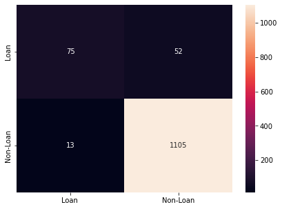

```python
cm=metrics.confusion_matrix(y_test, y_predict, labels=[1,0])

df_cm = pd.DataFrame(cm, index = [i for i in ["Loan","Non-Loan"]],
                  columns = [i for i in ["Loan ","Non-Loan"]])
plt.figure(figsize = (7,5))
sns.heatmap(df_cm, annot=True,fmt='g')
```

The confusion matrix

```python
print("classification  Matrix for logistic regression model :\n",classification_report(y_test,y_predict))
```

```
classification  Matrix for logistic regression model :
               precision    recall  f1-score   support

         0.0       0.96      0.99      0.97      1118
         1.0       0.85      0.59      0.70       127

    accuracy                           0.95      1245
   macro avg       0.90      0.79      0.83      1245
weighted avg       0.94      0.95      0.94      1245
```

###### Insights on test data prediction:

Precision: Out of all predicted values, what fraction are predicted correctly  
Recall(sensitivity or TPR): Out of all actual values how much fraction we identified correctly

- The model predicted correctly that the customer will have loan for 85% of time.
- The model predicted correctly that the customer will not have loan for 96% of time.
- The average f1-score is 83%

Score accuracy for test data using logistic regression model is 95%

### E. Balance the data using the right balancing technique. [2 Marks]

i. Check distribution of the target variable  
ii. Say output is class A : 20% and class B : 80%  
iii. Here you need to balance the target variable as 50:50.  
iv. Try appropriate method to achieve the same

```python
print("current distribution of the target variable:")
print(y.value_counts())
```

```
current distribution of the target variable:
LoanOnCard
0.0           4500
1.0            480
dtype: int64
```

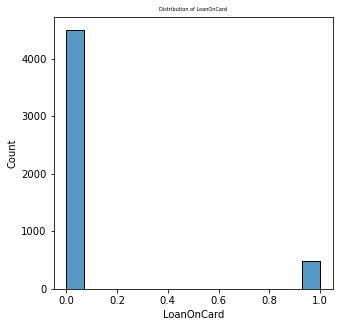

```python
plt.figure(figsize=(5,5))
sns.histplot(data=cust, x='LoanOnCard')
plt.title("Distribution of LoanOnCard",size=5)
plt.show()
```

- Around 10% of target variable LoanOnCard has value 1
- Around 90% of target variable LoanOnCard has value 0

```python
smote=SMOTE(random_state=1)
x_s,y_s=smote.fit_resample(X,y)
```

```python
print("Distribution of balanced target variable")
print(y_s.value_counts())
```

```
Distribution of balanced target variable
LoanOnCard
0.0           4500
1.0           4500
dtype: int64
```

The distribution is exactly equal i.e 50:50

### F. Again train the same previous model on balanced data. [1 Marks]

```python
X_train, X_test, y_train, y_test = train_test_split(x_s, y_s, test_size=0.25, random_state=1)
```

```python
logit_bal = LogisticRegression(solver='lbfgs', max_iter=3000)
logit_bal.fit(X_train, y_train)
y_predict = logit_bal.predict(X_test)

print('Accuracy on Training data:',logit_bal.score(X_train, y_train.values.ravel()))
print('Accuracy on Test data:',logit_bal.score(X_test, y_test.values.ravel()))
```

```
Accuracy on Training data: 0.9019259259259259
Accuracy on Test data: 0.9088888888888889
```

```python
coef_df = pd.DataFrame(logit_bal.coef_)
coef_df['intercept'] = logit_bal.intercept_
print(coef_df)
```

```
          0         1         2         3         4         5         6  \
0 -0.137228  0.134248  0.052896  0.608427  0.279016  1.634957 -0.000129

          7         8        9        10  intercept
0 -0.996942  4.236219 -0.75775 -1.125084  -7.431996
```

### G. Print evaluation metrics and clearly share differences observed. [2 Marks]

```python
print('Accuracy on Training data is {}'.format(logit_bal.score(X_train, y_train.values.ravel())))
print('Accuracy on Test data is {}'.format(logit_bal.score(X_test, y_test.values.ravel())))
```

```
Accuracy on Training data is 0.9019259259259259
Accuracy on Test data is 0.9088888888888889
```

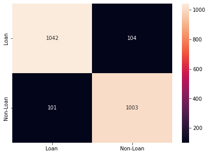

```python
cm=metrics.confusion_matrix(y_test, y_predict, labels=[1, 0])

df_cm = pd.DataFrame(cm, index = [i for i in ["Loan","Non-Loan"]],
                  columns = [i for i in ["Loan ","Non-Loan"]])
plt.figure(figsize = (7,5))
sns.heatmap(df_cm, annot=True,fmt='g')
```

The confusion matrix:

False Positives (FP): we incorrectly predicted that the number of customers will have loan ("Type I error") are 101. Falsely predict positive Type I error

```python
print("classification  Matrix for logistic regression model on balanced data :\n",classification_report(y_test,y_predict))
```

```
classification  Matrix for logistic regression model on balanced data :
               precision    recall  f1-score   support

         0.0       0.91      0.91      0.91      1104
         1.0       0.91      0.91      0.91      1146

    accuracy                           0.91      2250
   macro avg       0.91      0.91      0.91      2250
weighted avg       0.91      0.91      0.91      2250
```

We can see that the recall value increased so much. After balancing the target variable, the recall and f1-score are really good.

## 4. Performance Improvement: [10 Marks]

### A. Train a base model each for SVM, KNN. [4 Marks]

#### Training the model using SVM:

```python
#Training the model using SVM
from sklearn import svm
clf = svm.SVC(gamma=0.025, C=3)
```

```python
clf.fit(X_train, y_train.values.ravel())
```

```
SVC(C=3, gamma=0.025)
```

```python
y_base_pred = clf.predict(X_test)
```

```python
def getAccuracy(testSet, predictions):
    correct = 0
    for x in range(len(testSet)):
        if testSet[x]==predictions[x]:
            correct += 1
    return (correct/float(len(testSet))) * 100.0
```

```python
test_accuracy=getAccuracy(y_test["LoanOnCard"].tolist(),y_base_pred)
```

```python
print("Test score accuracy using SVM: {}".format(test_accuracy))
```

```
Test score accuracy using SVM: 96.35555555555555
```

```python
#sample actual Vs Predicted
y_grid = (np.column_stack([y_test, y_base_pred]))
print(y_grid)
```

```
[[1. 1.]
 [0. 0.]
 [1. 1.]
 ...
 [0. 0.]
 [1. 1.]
 [0. 0.]]
```

#### The accuracy of test score using SVM is 96.35%

```
Confusion Matrix
```

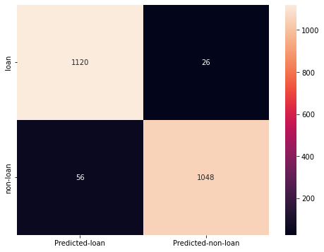

```python
print("Confusion Matrix")
cm_train=metrics.confusion_matrix(y_test, y_base_pred, labels=[1,0])

df_cm_train = pd.DataFrame(cm_train, index = [i for i in ["loan","non-loan"]],
                  columns = [i for i in ["Predicted-loan","Predicted-non-loan"]])
plt.figure(figsize = (8,6))
sns.heatmap(df_cm_train, annot=True,fmt='g')
```

#### The confusion matrix:

True Positives (TP): we correctly predicted that the number of customers will have loan are 1120

True Negatives (TN): we correctly predicted that the number of customers will not have loan are 1048

False Positives (FP): we incorrectly predicted that the number of customers will have loan ("Type I error") are 56. Falsely predict positive Type I error

False Negatives (FN): we incorrectly predicted that the number of customers will not have loan ("Type II error") are 26. Falsely predict negative Type II error

```python
print("classification  Matrix for SVM model:\n",classification_report(y_test,y_base_pred))
```

```
classification  Matrix for SVM model:
               precision    recall  f1-score   support

         0.0       0.98      0.95      0.96      1104
         1.0       0.95      0.98      0.96      1146

    accuracy                           0.96      2250
   macro avg       0.96      0.96      0.96      2250
weighted avg       0.96      0.96      0.96      2250
```

#### Insights on SVM model:

Precision: Out of all predicted values, what fraction are predicted correctly  
Recall(sensitivity or TPR): Out of all actual values how much fraction we identified correctly

- The model predicted correctly that the customer will have loan for 95% of time.
- The model predicted correctly that the customer will not have loan for 98% of time.
- Average f1-score is 96% #### Average score accuracy on test data using SVM model is 96%

#### Training the model using KNN classifier:

```python
#Training the model using KNN
knn = KNeighborsClassifier(n_neighbors=5,metric='euclidean')
```

```python
# Call Nearest Neighbour algorithm

knn.fit(X_train, y_train)
```

```
KNeighborsClassifier(metric='euclidean')
```

```python
# Call Nearest Neighbour algorithm

knn.score(X_train, y_train)
```

```
0.9414814814814815
```

```python
predicted_labels_train = knn.predict(X_train)
```

```
Confusion Matrix
```

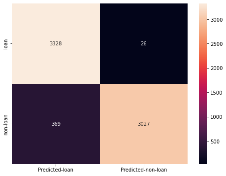

```python
print("Confusion Matrix")
cm_train=metrics.confusion_matrix(y_train, predicted_labels_train, labels=[1,0])

df_cm_train = pd.DataFrame(cm_train, index = [i for i in ["loan","non-loan"]],
                  columns = [i for i in ["Predicted-loan","Predicted-non-loan"]])
plt.figure(figsize = (8,6))
sns.heatmap(df_cm_train, annot=True,fmt='g')
```

The confusion matrix:

True Positives (TP): we correctly predicted that the number of customers will have loan are 3328

True Negatives (TN): we correctly predicted that the number of customers will not have loan are 3027

False Positives (FP): we incorrectly predicted that the number of customers will have loan ("Type I error") are 369. Falsely predict positive Type I error

False Negatives (FN): we incorrectly predicted that the number of customers will not have loan ("Type II error") are 26. Falsely predict negative Type II error

```python
print("classification  Matrix for KNN model:\n",classification_report(y_train,predicted_labels_train))
```

```
classification  Matrix for KNN model:
               precision    recall  f1-score   support

         0.0       0.99      0.89      0.94      3396
         1.0       0.90      0.99      0.94      3354

    accuracy                           0.94      6750
   macro avg       0.95      0.94      0.94      6750
weighted avg       0.95      0.94      0.94      6750
```

###### Insights on train data prediction before hyperparameter tuning:

Precision: Out of all predicted values, what fraction are predicted correctly  
Recall(sensitivity or TPR): Out of all actual values how much fraction we identified correctly

- The model predicted correctly that the customer will loan for 90% of time.
- The model predicted correctly that the customer will not have loan for 99% of time.
- Average f1-score is 94%

Average score accuracy on train data using KNN model is 94%

```python
predicted_labels_test = knn.predict(X_test)
```

```
Confusion Matrix
```

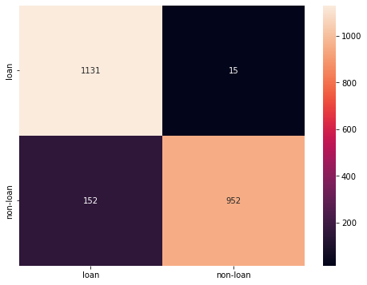

```python
# calculate accuracy measures and confusion matrix
from sklearn import metrics

print("Confusion Matrix")
cm_test=metrics.confusion_matrix(y_test, predicted_labels_test, labels=[1,0])

df_cm_test = pd.DataFrame(cm_test, index = [i for i in ["loan","non-loan"]],
                  columns = [i for i in ["loan","non-loan"]])
plt.figure(figsize = (8,6))
sns.heatmap(df_cm_test, annot=True,fmt='g')
```

```python
print("classification  Matrix for KNN model on test data:\n",classification_report(y_test,predicted_labels_test))
```

```
classification  Matrix for KNN model on test data:
               precision    recall  f1-score   support

         0.0       0.98      0.86      0.92      1104
         1.0       0.88      0.99      0.93      1146

    accuracy                           0.93      2250
   macro avg       0.93      0.92      0.93      2250
weighted avg       0.93      0.93      0.93      2250
```

###### Insights on test data prediction before hyperparameter tuning:

Precision: Out of all predicted values, what fraction are predicted correctly  
Recall(sensitivity or TPR): Out of all actual values how much fraction we identified correctly

- The model predicted correctly that the customer will loan for 88% of time.
- The model predicted correctly that the customer will not have loan for 98% of time.
- Average f1-score is 93%

Average score accuracy on test data using KNN model is 93%

```python
#Finding the best K value
train_score=[]
test_score=[]
for k in range(1,51):
    knn = KNeighborsClassifier(n_neighbors= k , metric = 'euclidean' )
    knn.fit(X_train, y_train.values.ravel())
    train_score.append(knn.score(X_train, y_train.values.ravel()))
    test_score.append(knn.score(X_test, y_test.values.ravel()))
```

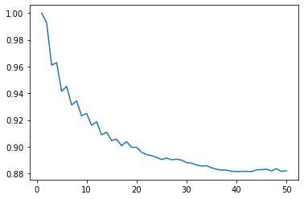

```python
plt.plot(range(1,51),train_score)
plt.show()
```

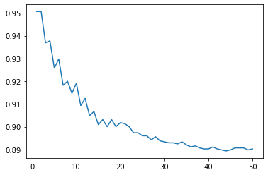

```python
plt.plot(range(1,51),test_score)
plt.show()
```

The accuracy declines as we increase the K value in both Train and test dataset. The best value of K lies between 1 and 10.

```python
for k in range(1,10):
    knn = KNeighborsClassifier(n_neighbors= k , metric = 'euclidean' )
    knn.fit(X_train, y_train.values.ravel())
    predicted_labels = knn.predict(X_test)
    print('Accuracy on Training data for k {} is {}:'.format(k,knn.score(X_train, y_train.values.ravel())))
    print('Accuracy on Test data for k {} is {}:'.format(k,knn.score(X_test, y_test.values.ravel())))
    print("classification  Matrix:\n",classification_report(y_test,predicted_labels))
```

```
Accuracy on Training data for k 1 is 1.0:
Accuracy on Test data for k 1 is 0.9506666666666667:
classification  Matrix:
               precision    recall  f1-score   support

         0.0       0.99      0.91      0.95      1104
         1.0       0.92      0.99      0.95      1146

    accuracy                           0.95      2250
   macro avg       0.95      0.95      0.95      2250
weighted avg       0.95      0.95      0.95      2250

Accuracy on Training data for k 2 is 0.9925925925925926:
Accuracy on Test data for k 2 is 0.9506666666666667:
classification  Matrix:
               precision    recall  f1-score   support

         0.0       0.97      0.93      0.95      1104
         1.0       0.93      0.97      0.95      1146

    accuracy                           0.95      2250
   macro avg       0.95      0.95      0.95      2250
weighted avg       0.95      0.95      0.95      2250

Accuracy on Training data for k 3 is 0.961037037037037:
Accuracy on Test data for k 3 is 0.9368888888888889:
classification  Matrix:
               precision    recall  f1-score   support

         0.0       0.99      0.88      0.93      1104
         1.0       0.90      0.99      0.94      1146

    accuracy                           0.94      2250
   macro avg       0.94      0.94      0.94      2250
weighted avg       0.94      0.94      0.94      2250

Accuracy on Training data for k 4 is 0.9628148148148148:
Accuracy on Test data for k 4 is 0.9377777777777778:
classification  Matrix:
               precision    recall  f1-score   support
```

[output cut: 52 more lines]

```
    accuracy                           0.92      2250
   macro avg       0.93      0.92      0.92      2250
weighted avg       0.93      0.92      0.92      2250

Accuracy on Training data for k 9 is 0.9231111111111111:
Accuracy on Test data for k 9 is 0.9146666666666666:
classification  Matrix:
               precision    recall  f1-score   support

         0.0       0.98      0.85      0.91      1104
         1.0       0.87      0.98      0.92      1146

    accuracy                           0.91      2250
   macro avg       0.92      0.91      0.91      2250
weighted avg       0.92      0.91      0.91      2250
```

#### From the above accuracy results and classification matrix, k=4 has given balanced recall and precision. We have achieved 94% accuracy in Test dataset using KNN classifier model.

### B. Tune parameters for each of the models wherever required and finalize a model. [3 Marks]

(Optional: Experiment with various Hyperparameters - Research required)

#### Fine tuning SVM model using various Hyperparameters:

#### Trying SVM with linear kernel:

```python
from sklearn import svm
clf = svm.SVC(kernel="linear", gamma=0.025, C=3)
```

```python
clf.fit(X_train, y_train.values.ravel())
```

```
SVC(C=3, gamma=0.025, kernel='linear')
```

```python
y_pred = clf.predict(X_test)
```

```python
def getAccuracy(testSet, predictions):
    correct = 0
    for x in range(len(testSet)):
        if testSet[x]==predictions[x]:
            correct += 1
    return (correct/float(len(testSet))) * 100.0
```

```python
getAccuracy(y_test["LoanOnCard"].tolist(),y_pred)
```

```
90.93333333333334
```

#### When kernel='linear', gamma=0.025, C=3, the SVM model score accuracy is 90.93%

#### Trying SVM with rbf kernel:

```python
def rbf_model(g,c):
    for gi in g:
        for ci in c:
            res={}
            clf_rbf = svm.SVC(kernel="rbf", gamma=gi, C=ci)
            clf_rbf.fit(X_train, y_train.values.ravel())
            y_pred = clf_rbf.predict(X_test)
            acc=getAccuracy(y_test["LoanOnCard"].tolist(),y_pred)
            res["g"]=gi
            res["ci"]=ci
            res["acc"]=acc
            print(res)
```

```python
g=[0.025,0.05,0.075,0.1,0.2,0.5,0.7,1.0,2.0,3.0,4.0,5.0]
c=[1,3,5,7,9,11]
rbf_model(g,c)
```

```
{'g': 0.025, 'ci': 1, 'acc': 94.75555555555556}
{'g': 0.025, 'ci': 3, 'acc': 96.35555555555555}
{'g': 0.025, 'ci': 5, 'acc': 96.62222222222222}
{'g': 0.025, 'ci': 7, 'acc': 96.97777777777777}
{'g': 0.025, 'ci': 9, 'acc': 97.02222222222223}
{'g': 0.025, 'ci': 11, 'acc': 97.06666666666666}
{'g': 0.05, 'ci': 1, 'acc': 94.31111111111112}
{'g': 0.05, 'ci': 3, 'acc': 95.51111111111112}
{'g': 0.05, 'ci': 5, 'acc': 95.42222222222222}
{'g': 0.05, 'ci': 7, 'acc': 95.6888888888889}
{'g': 0.05, 'ci': 9, 'acc': 95.73333333333333}
{'g': 0.05, 'ci': 11, 'acc': 95.73333333333333}
{'g': 0.075, 'ci': 1, 'acc': 93.28888888888889}
{'g': 0.075, 'ci': 3, 'acc': 94.4888888888889}
{'g': 0.075, 'ci': 5, 'acc': 94.57777777777778}
{'g': 0.075, 'ci': 7, 'acc': 94.57777777777778}
{'g': 0.075, 'ci': 9, 'acc': 94.66666666666667}
{'g': 0.075, 'ci': 11, 'acc': 94.62222222222222}
{'g': 0.1, 'ci': 1, 'acc': 92.62222222222222}
{'g': 0.1, 'ci': 3, 'acc': 93.42222222222222}
{'g': 0.1, 'ci': 5, 'acc': 93.46666666666667}
{'g': 0.1, 'ci': 7, 'acc': 93.5111111111111}
{'g': 0.1, 'ci': 9, 'acc': 93.42222222222222}
{'g': 0.1, 'ci': 11, 'acc': 93.42222222222222}
{'g': 0.2, 'ci': 1, 'acc': 90.35555555555555}
{'g': 0.2, 'ci': 3, 'acc': 91.06666666666666}
{'g': 0.2, 'ci': 5, 'acc': 91.02222222222223}
{'g': 0.2, 'ci': 7, 'acc': 91.02222222222223}
{'g': 0.2, 'ci': 9, 'acc': 91.02222222222223}
{'g': 0.2, 'ci': 11, 'acc': 91.02222222222223}
{'g': 0.5, 'ci': 1, 'acc': 86.0}
{'g': 0.5, 'ci': 3, 'acc': 86.93333333333332}
{'g': 0.5, 'ci': 5, 'acc': 86.93333333333332}
{'g': 0.5, 'ci': 7, 'acc': 86.93333333333332}
{'g': 0.5, 'ci': 9, 'acc': 86.93333333333332}
{'g': 0.5, 'ci': 11, 'acc': 86.93333333333332}
{'g': 0.7, 'ci': 1, 'acc': 82.88888888888889}
{'g': 0.7, 'ci': 3, 'acc': 84.75555555555555}
{'g': 0.7, 'ci': 5, 'acc': 84.75555555555555}
{'g': 0.7, 'ci': 7, 'acc': 84.75555555555555}
```

[output cut: 17 more lines]

```
{'g': 3.0, 'ci': 7, 'acc': 69.77777777777779}
{'g': 3.0, 'ci': 9, 'acc': 69.77777777777779}
{'g': 3.0, 'ci': 11, 'acc': 69.77777777777779}
{'g': 4.0, 'ci': 1, 'acc': 68.13333333333334}
{'g': 4.0, 'ci': 3, 'acc': 68.75555555555556}
{'g': 4.0, 'ci': 5, 'acc': 68.75555555555556}
{'g': 4.0, 'ci': 7, 'acc': 68.75555555555556}
{'g': 4.0, 'ci': 9, 'acc': 68.75555555555556}
{'g': 4.0, 'ci': 11, 'acc': 68.75555555555556}
{'g': 5.0, 'ci': 1, 'acc': 67.73333333333333}
{'g': 5.0, 'ci': 3, 'acc': 68.22222222222221}
{'g': 5.0, 'ci': 5, 'acc': 68.22222222222221}
{'g': 5.0, 'ci': 7, 'acc': 68.22222222222221}
{'g': 5.0, 'ci': 9, 'acc': 68.22222222222221}
{'g': 5.0, 'ci': 11, 'acc': 68.22222222222221}
```

when gamma is less and C is greater the score accuracy increases. Let us explore more combination of gamma and c.

```python
g=[0.001,0.010,0.015,0.025]
c=[15,17,19,21,23,25,30,35,40,45,50,60,70,80]
rbf_model(g,c)
```

```
{'g': 0.001, 'ci': 15, 'acc': 95.77777777777777}
{'g': 0.001, 'ci': 17, 'acc': 96.0}
{'g': 0.001, 'ci': 19, 'acc': 96.13333333333334}
{'g': 0.001, 'ci': 21, 'acc': 96.26666666666667}
{'g': 0.001, 'ci': 23, 'acc': 96.22222222222221}
{'g': 0.001, 'ci': 25, 'acc': 96.26666666666667}
{'g': 0.001, 'ci': 30, 'acc': 96.62222222222222}
{'g': 0.001, 'ci': 35, 'acc': 96.62222222222222}
{'g': 0.001, 'ci': 40, 'acc': 96.62222222222222}
{'g': 0.001, 'ci': 45, 'acc': 96.57777777777777}
{'g': 0.001, 'ci': 50, 'acc': 96.66666666666667}
{'g': 0.001, 'ci': 60, 'acc': 96.75555555555555}
{'g': 0.001, 'ci': 70, 'acc': 96.84444444444445}
{'g': 0.001, 'ci': 80, 'acc': 96.8}
{'g': 0.01, 'ci': 15, 'acc': 97.55555555555556}
{'g': 0.01, 'ci': 17, 'acc': 97.6}
{'g': 0.01, 'ci': 19, 'acc': 97.73333333333333}
{'g': 0.01, 'ci': 21, 'acc': 97.6888888888889}
{'g': 0.01, 'ci': 23, 'acc': 97.6888888888889}
{'g': 0.01, 'ci': 25, 'acc': 97.6888888888889}
{'g': 0.01, 'ci': 30, 'acc': 97.77777777777777}
{'g': 0.01, 'ci': 35, 'acc': 97.82222222222222}
{'g': 0.01, 'ci': 40, 'acc': 97.86666666666667}
{'g': 0.01, 'ci': 45, 'acc': 97.91111111111111}
{'g': 0.01, 'ci': 50, 'acc': 97.91111111111111}
{'g': 0.01, 'ci': 60, 'acc': 98.0}
{'g': 0.01, 'ci': 70, 'acc': 97.91111111111111}
{'g': 0.01, 'ci': 80, 'acc': 97.82222222222222}
{'g': 0.015, 'ci': 15, 'acc': 97.73333333333333}
{'g': 0.015, 'ci': 17, 'acc': 97.77777777777777}
{'g': 0.015, 'ci': 19, 'acc': 97.73333333333333}
{'g': 0.015, 'ci': 21, 'acc': 97.77777777777777}
{'g': 0.015, 'ci': 23, 'acc': 97.77777777777777}
{'g': 0.015, 'ci': 25, 'acc': 97.86666666666667}
{'g': 0.015, 'ci': 30, 'acc': 97.73333333333333}
{'g': 0.015, 'ci': 35, 'acc': 97.64444444444445}
{'g': 0.015, 'ci': 40, 'acc': 97.73333333333333}
{'g': 0.015, 'ci': 45, 'acc': 97.73333333333333}
{'g': 0.015, 'ci': 50, 'acc': 97.73333333333333}
{'g': 0.015, 'ci': 60, 'acc': 97.6888888888889}
{'g': 0.015, 'ci': 70, 'acc': 97.73333333333333}
{'g': 0.015, 'ci': 80, 'acc': 97.6888888888889}
{'g': 0.025, 'ci': 15, 'acc': 97.06666666666666}
{'g': 0.025, 'ci': 17, 'acc': 96.97777777777777}
{'g': 0.025, 'ci': 19, 'acc': 96.93333333333334}
{'g': 0.025, 'ci': 21, 'acc': 96.97777777777777}
{'g': 0.025, 'ci': 23, 'acc': 96.93333333333334}
{'g': 0.025, 'ci': 25, 'acc': 96.93333333333334}
{'g': 0.025, 'ci': 30, 'acc': 96.8}
{'g': 0.025, 'ci': 35, 'acc': 96.8}
{'g': 0.025, 'ci': 40, 'acc': 96.84444444444445}
{'g': 0.025, 'ci': 45, 'acc': 96.84444444444445}
{'g': 0.025, 'ci': 50, 'acc': 96.8}
{'g': 0.025, 'ci': 60, 'acc': 96.84444444444445}
{'g': 0.025, 'ci': 70, 'acc': 96.84444444444445}
{'g': 0.025, 'ci': 80, 'acc': 96.8}
```

#### When kernel='rbf', gamma=0.01, C=60 the model score accuracy is 98%

#### Fine tuning KNN model using various Hyperparameters:

```python
#Try with various hyperparameters and to indentify the best model
from sklearn.model_selection import GridSearchCV
leaf_size = list(range(1,10))
n_neighbors = list(range(3,10))
p=[1,2]
#prepare hyperparameters dict
hyperparameters = dict(leaf_size=leaf_size, n_neighbors=n_neighbors, p=p)
#Lets create new KNN object
knn_hyper = KNeighborsClassifier()
#We will use GridSearch
clf = GridSearchCV(knn_hyper, hyperparameters, cv=10)
#Fit the model
knn_best = clf.fit(X_train, y_train.values.ravel())
#Print the best values of Hyperparameters
print('Best of leaf_size:', knn_best.best_estimator_.get_params()['leaf_size'])
print('Best of p:', knn_best.best_estimator_.get_params()['p'])
print('Best of n_neighbors:', knn_best.best_estimator_.get_params()['n_neighbors'])
```

```
Best of leaf_size: 1
Best of p: 1
Best of n_neighbors: 4
```

```python
#Lets calculate the score using the best of hypermeters identified above.
hyperparameters=dict(leaf_size=[1], n_neighbors=[4], p=[1])
#Use GridSearch
clf = GridSearchCV(knn_hyper, hyperparameters, cv=10)
#Fit the model
knn_best_model = clf.fit(X_train, y_train.values.ravel())
```

```python
predicted_labels = knn_best_model.predict(X_test)
print('Accuracy on Training data using KNN model after hyperparameter tuning is {}:'.format(knn_best_model.score(X_train, y_train.values.ravel())))
print('Accuracy on Test data using KNN model after hyperparameter tuning is {}:'.format(knn_best_model.score(X_test, y_test.values.ravel())))
print("classification  Matrix for KNN model after hyperparameter tuning:\n",classification_report(y_test,predicted_labels))
```

```
Accuracy on Training data using KNN model after hyperparameter tuning is 0.9752592592592593:
Accuracy on Test data using KNN model after hyperparameter tuning is 0.9515555555555556:
classification  Matrix for KNN model after hyperparameter tuning:
               precision    recall  f1-score   support

         0.0       0.98      0.92      0.95      1104
         1.0       0.93      0.98      0.95      1146

    accuracy                           0.95      2250
   macro avg       0.95      0.95      0.95      2250
weighted avg       0.95      0.95      0.95      2250
```

#### Insights on test data prediction after hyperparameter tuning:

Precision: Out of all predicted values, what fraction are predicted correctly  
Recall(sensitivity or TPR): Out of all actual values how much fraction we identified correctly

- The model predicted correctly that the customer will have loan for 93% of time.
- The model predicted correctly that the customer will not have loan for 98% of time.
- Average f1-score is 95%
- Average score accuracy on test data using KNN model is 95%

### C. Print evaluation metrics for final model. [1 Marks]

#### Results of SVM and KNN models after hyperparameter tuning:

- Using SVM model, when kernel='linear', gamma=0.025, C=3, the SVM model score accuracy is 90.93%
- Using SVM model, When kernel='rbf', gamma=0.01, C=60 the model score accuracy is 98%
- Using KNN model, score accuracy on test population is 95% #### The final model selected is SVM model with hyperparameters kernel='rbf', gamma=0.01, C=60. Thi smodel gives 98% accuracy.

```python
clf_rbf = svm.SVC(kernel="rbf", gamma=0.01, C=60)
clf_rbf.fit(X_train, y_train.values.ravel())
y_pred = clf_rbf.predict(X_test)
acc=getAccuracy(y_test["LoanOnCard"].tolist(),y_pred)
print("Score accuracy using SVM model:{}".format(acc))
```

```
Score accuracy using SVM model:98.0
```

```
Confusion Matrix
```

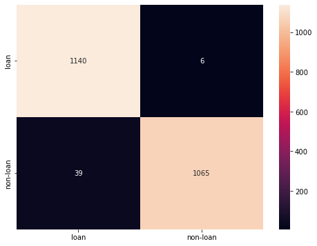

```python
# calculate accuracy measures and confusion matrix
from sklearn import metrics

print("Confusion Matrix")
cm_test=metrics.confusion_matrix(y_test, y_pred, labels=[1,0])

df_cm_test = pd.DataFrame(cm_test, index = [i for i in ["loan","non-loan"]],
                  columns = [i for i in ["loan","non-loan"]])
plt.figure(figsize = (8,6))
sns.heatmap(df_cm_test, annot=True,fmt='g')
```

#### The confusion matrix:

True Positives (TP): we correctly predicted that the number of customers will have loan are 1140

True Negatives (TN): we correctly predicted that the number of customers will not have loan are 1065

False Positives (FP): we incorrectly predicted that the number of customers will have loan ("Type I error") are 39. Falsely predict positive Type I error

False Negatives (FN): we incorrectly predicted that the number of customers will not have loan ("Type II error") are 6. Falsely predict negative Type II error

```python
print("classification  Matrix for SVM model after hyperparameter tuning:\n",classification_report(y_test,y_pred))
```

```
classification  Matrix for SVM model after hyperparameter tuning:
               precision    recall  f1-score   support

         0.0       0.99      0.96      0.98      1104
         1.0       0.97      0.99      0.98      1146

    accuracy                           0.98      2250
   macro avg       0.98      0.98      0.98      2250
weighted avg       0.98      0.98      0.98      2250
```

#### Insights on SVM model prediction using kernel='rbf', gamma=0.01, C=60:

Precision: Out of all predicted values, what fraction are predicted correctly  
Recall(sensitivity or TPR): Out of all actual values how much fraction we identified correctly

- The model predicted correctly that the customer will have loan for 97% of time.
- The model predicted correctly that the customer will not have loan for 99% of time.
- Average f1-score is 98% #### Average score accuracy on test data using SVM model is 98%

### D. Share improvement achieved from base model to final model. [2 Marks]

#### Final model achieved:

- The final model selected is SVM model-rbf kernel, gamma=0.01, C=60 and the score accuracy achieved is 98%. There is a +2% improvement is score accuracy.

```
Confusion Matrix for base model:
```

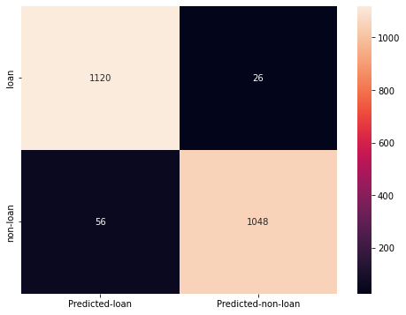

```python
print("Confusion Matrix for base model:")
cm_train=metrics.confusion_matrix(y_test, y_base_pred, labels=[1,0])

df_cm_train = pd.DataFrame(cm_train, index = [i for i in ["loan","non-loan"]],
                  columns = [i for i in ["Predicted-loan","Predicted-non-loan"]])
plt.figure(figsize = (8,6))
sns.heatmap(df_cm_train, annot=True,fmt='g')
```

```
Confusion Matrix for final model:
```

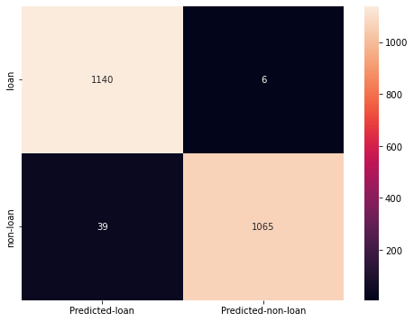

```python
print("Confusion Matrix for final model:")
cm_train=metrics.confusion_matrix(y_test, y_pred, labels=[1,0])

df_cm_train = pd.DataFrame(cm_train, index = [i for i in ["loan","non-loan"]],
                  columns = [i for i in ["Predicted-loan","Predicted-non-loan"]])
plt.figure(figsize = (8,6))
sns.heatmap(df_cm_train, annot=True,fmt='g')
```

#### Improvements from confusion matrix:

- True Positives (TP) improved from 1120 to 1140
- True Negatives (TN) improved from 1048 to 1065
- False Positives (FP) ("Type I error") decreased from 56 to 39
- False Negatives (FN) ("Type II error") decreased from 26 to 6

```python
print("classification Matrix for SVM base model :\n",classification_report(y_test,y_base_pred))
print("classification Matrix for SVM final model:\n",classification_report(y_test,y_pred))
```

```
classification Matrix for SVM base model :
               precision    recall  f1-score   support

         0.0       0.98      0.95      0.96      1104
         1.0       0.95      0.98      0.96      1146

    accuracy                           0.96      2250
   macro avg       0.96      0.96      0.96      2250
weighted avg       0.96      0.96      0.96      2250

classification Matrix for SVM final model:
               precision    recall  f1-score   support

         0.0       0.99      0.96      0.98      1104
         1.0       0.97      0.99      0.98      1146

    accuracy                           0.98      2250
   macro avg       0.98      0.98      0.98      2250
weighted avg       0.98      0.98      0.98      2250
```

#### Improvements from classification matrix:

- Score accuracy improved from 96% to 98%
- f1-score improved from 96% to 98%
- recall improved from 96% to 98%
- Precision for loan customers prediction improved from 95% to 97%
- Precision for non-loan customers predictions improved from 98% to 99%